# Vowel compression

# Load required packages

```r
library("tidyr");
library("plyr");
library("dplyr");
```

```r
library("ggplot2");
library("visreg");
library("mgcv");
library("itsadug");
```

# 1 Introduction

## 1.1 Read data

```r
df <- readRDS("C:/Users/Jidde/Desktop/analysis/data/modelling_C_center.rds")
df <- rename(df, onset_type = condition)
df <- rename(df, item_pair = cluster)
```

## 1.2 Convert factors and subset data

```r
# convert to factors/numeric:
df$onset_type <- as.factor(df$onset_type)
df$subj <- as.factor(df$subj)

# remove all the recordings without a speech rate measure:
df <- df %>% drop_na(duration.tt)

# center duration.tt, so it's easier to interpret.
df$duration.tt.c <- scale(df$duration.tt, scale = F)

# Change order of levels in item_pair
df$item_pair <- factor(df$item_pair, levels = c("sp", "sm", "sx", "spr"))

# Sort data
df <- df[order(df$subj, df$recording.no),]

# Rename CTRL
df$group <- revalue(df$group, c("CTRL"="typical"))
df$group<- relevel(df$group, ref = "PD")

# create df without spr:
df.nospr <- df[! df$item_pair == "spr", ]
df.nospr <- droplevels(df.nospr)
levels(df.nospr$item_pair)
```

```
## [1] "sp" "sm" "sx"
```

```r
table(df.nospr$subj, df.nospr$prompt)
```

```
##
##          oma's pad oma spat opa's gat opa's mat opa schat opa Smat
##   CTRL01        10        8        10         9         9        9
##   CTRL02        10       10         9        10        10       10
##   CTRL03        10       10        10        10        10       10
##   CTRL04         9       11         9         8         9        7
##   CTRL05        10       10        10         0        10       10
##   CTRL06        10       10        10        10        10       10
##   CTRL07        10       10         9        10        10        9
##   CTRL08         9       10        10        10        10       11
##   CTRL09        10       10        10        10        10       10
##   CTRL10        10       10        10        10         9        8
##   CTRL11        10       11        10        10         9       11
##   CTRL12        10       10        10        10        10        6
##   CTRL13        10        9        10         9        10        9
##   CTRL14        10       10        10        10         8       10
##   CTRL15        10       10        11        11        10       10
##   CTRL16         9        9         9         9         9       10
##   CTRL17        10        7         6         7         6        7
##   CTRL18        10       10        10        10        10       10
##   CTRL19         4        4         4         4         4        2
##   CTRL20        10        9        10        10        10       10
##   CTRL21        10       11        10        11        11       10
##   CTRL23        10       10         9        11         5       10
##   CTRL24        10       10        10        10        10        9
##   CTRL25        10       10         9        10        10       10
##   PD01           9       10         7         9        10        9
##   PD02          10       10         7         8        10        7
##   PD03          10       10        10        10        10       10
##   PD04          10        9         9         8         9        9
##   PD05           9       10        10         9        10       10
##   PD06          10       10         9        10        10       10
##   PD07          10       10        10         8         9        8
##   PD08           9       10         9         8        10        9
##   PD09          10       11        10         9         9        9
##   PD10          10       10        10        10        10        7
##   PD11          10       10         9         9         8        4
##   PD12          10       10        10        10        10       10
##   PD13          10       10        10        10        10       10
##   PD14          10       10         8         8         9        6
##   PD15          10       10         8        10        10        9
##   PD16          10       10        10        10        10        8
##   PD17          10       10        11        10        10        9
##   PD18          10       10        10         8         9       10
##   PD19           2        2         0         2         0        0
##   PD21          10        9        10        10        10       10
##   PD22          10       10        10        10        10        9
##   PD23          10        9        10         8         9        5
##   PD25          10       10         0        10         0       10
```

```r
df.nospr$onset_type <- recode_factor(df.nospr$onset_type, C = "singleton",
                                CC = "cluster")
rm(df)
```

Create ordered factors:

```r
df.nospr$group.ord <- as.ordered(df.nospr$group)
contrasts(df.nospr$group.ord) <- "contr.treatment"

df.nospr$gender.ord <- as.ordered(df.nospr$gender)
contrasts(df.nospr$gender.ord) <- "contr.treatment"
```

Create binary dummy variables:

```r
df.nospr$IsTP <- (df.nospr$group == "typical")*1
df.nospr$IsMale <- (df.nospr$gender == "M")*1
```

# 2 GAM modelsfor rightward shift rightmost C

In a CCV complex onset the rightmost C in the onset should show a rightward shift towards the vowel in comparison to the C in a CV onset. We hypothesize that this shift may be less pronounced for the patient group, as they may show a stronger preference for inphase coordination. In this analysis we compare /sp/ to /p/, /sm/ to /m/, /sx/ to /x/ and /spr/ to /pr/. As a start, I’ve included the ‘item_pair’ variable and the ‘onset_type’ (simple vs. complex onset) variable.

## 2.1 Some plots

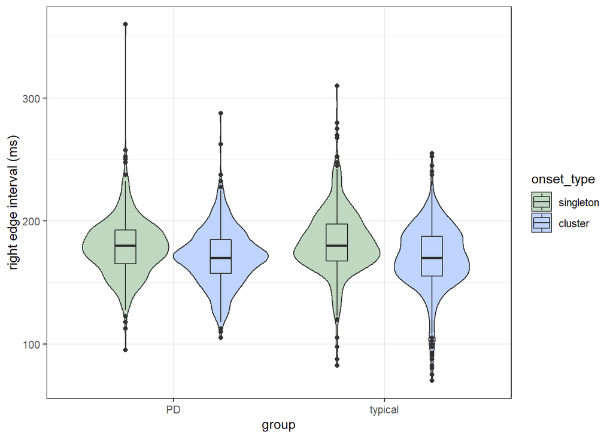

```r
dodge = .5
dodge <- position_dodge(width = 0.9)

#right edge shift
ggplot(df.nospr, aes(x=group, y=rightedge.lag, fill=onset_type)) + geom_violin() + geom_boxplot(width=.2, position = dodge) + labs(y = "right edge interval (ms)") + scale_fill_manual(values=c("#bfd8bf", "#bfd4ff")) + theme_bw()
```

```r
#ggplot(df.nospr[df.nospr$item_pair == "sp",], aes(x=group, y=rightedge.lag, fill=onset_type)) + geom_violin(trim=FALSE) + labs(y = "left edge interval (ms)") + geom_boxplot(width=.2, position = dodge) + scale_fill_manual(values=c("#bfd8bf", "#ffbfbf"))  + theme_bw()

#ggplot(df.nospr[df.nospr$item_pair == "sm",], aes(x=group, y=rightedge.lag, fill=onset_type)) + geom_violin(trim=FALSE) + labs(y = "left edge interval (ms)") + geom_boxplot(width=.2, position = dodge)

#ggplot(df.nospr[df.nospr$item_pair == "sx",], aes(x=group, y=rightedge.lag, fill=onset_type)) + geom_violin(trim=FALSE) + labs(y = "left edge interval (ms)") + geom_boxplot(width=.2, position = dodge)
```

## 2.2 Hypothesis test

Base model:

```r
summary(mBase <- bam(rightedge.lag ~ s(subj, bs='re'), data=df.nospr, method = "ML"))
```

```
##
## Family: gaussian
## Link function: identity
##
## Formula:
## rightedge.lag ~ s(subj, bs = "re")
##
## Parametric coefficients:
##             Estimate Std. Error t value Pr(>|t|)
## (Intercept)  175.982      2.783   63.23   <2e-16 ***
## ---
## Signif. codes:  0 '***' 0.001 '**' 0.01 '*' 0.05 '.' 0.1 ' ' 1
##
## Approximate significance of smooth terms:
##           edf Ref.df     F p-value
## s(subj) 45.04     46 49.05  <2e-16 ***
## ---
## Signif. codes:  0 '***' 0.001 '**' 0.01 '*' 0.05 '.' 0.1 ' ' 1
##
## R-sq.(adj) =  0.485   Deviance explained = 49.5%
## -ML =  10440  Scale est. = 327.45    n = 2398
```

OK.

Add onset_type:

```r
summary(m1 <- bam(rightedge.lag ~ onset_type + s(subj, bs='re'), data=df.nospr, method = "ML"))
```

```
##
## Family: gaussian
## Link function: identity
##
## Formula:
## rightedge.lag ~ onset_type + s(subj, bs = "re")
##
## Parametric coefficients:
##                   Estimate Std. Error t value Pr(>|t|)
## (Intercept)       181.0595     2.7999   64.67   <2e-16 ***
## onset_typecluster -10.2558     0.7101  -14.44   <2e-16 ***
## ---
## Signif. codes:  0 '***' 0.001 '**' 0.01 '*' 0.05 '.' 0.1 ' ' 1
##
## Approximate significance of smooth terms:
##           edf Ref.df     F p-value
## s(subj) 45.11     46 53.23  <2e-16 ***
## ---
## Signif. codes:  0 '***' 0.001 '**' 0.01 '*' 0.05 '.' 0.1 ' ' 1
##
## R-sq.(adj) =  0.527   Deviance explained = 53.6%
## -ML =  10340  Scale est. = 300.91    n = 2398
```

```r
compareML(mBase, m1)
```

```
## mBase: rightedge.lag ~ s(subj, bs = "re")
##
## m1: rightedge.lag ~ onset_type + s(subj, bs = "re")
```

```
##
## Chi-square test of ML scores
## -----
##   Model    Score Edf Difference    Df  p.value Sig.
## 1 mBase 10440.27   2
## 2    m1 10340.29   3     99.989 1.000  < 2e-16  ***
##
## AIC difference: 201.71, model m1 has lower AIC.
```

Yes.

Check if we need to fit it with scaled-t or log:

```r
summary(m1scat <- bam(rightedge.lag ~ onset_type + s(subj, bs='re'), data=df.nospr, family = "scat", discrete = T))
```

```
##
## Family: Scaled t(3.85,12.303)
## Link function: identity
##
## Formula:
## rightedge.lag ~ onset_type + s(subj, bs = "re")
##
## Parametric coefficients:
##                   Estimate Std. Error t value Pr(>|t|)
## (Intercept)       179.5342     2.5912   69.29   <2e-16 ***
## onset_typecluster  -9.5820     0.6026  -15.90   <2e-16 ***
## ---
## Signif. codes:  0 '***' 0.001 '**' 0.01 '*' 0.05 '.' 0.1 ' ' 1
##
## Approximate significance of smooth terms:
##           edf Ref.df     F p-value
## s(subj) 45.17     46 64.81  <2e-16 ***
## ---
## Signif. codes:  0 '***' 0.001 '**' 0.01 '*' 0.05 '.' 0.1 ' ' 1
##
## R-sq.(adj) =  0.509   Deviance explained = 43.1%
## fREML = 4024.1  Scale est. = 1         n = 2398
```

```r
summary(m1log <- bam(rightedge.lag ~ onset_type + s(subj, bs='re'), data=df.nospr, family =Gamma(link=log)))
```

```
##
## Family: Gamma
## Link function: log
##
## Formula:
## rightedge.lag ~ onset_type + s(subj, bs = "re")
##
## Parametric coefficients:
##                    Estimate Std. Error t value Pr(>|t|)
## (Intercept)        5.193284   0.016298  318.65   <2e-16 ***
## onset_typecluster -0.059408   0.004131  -14.38   <2e-16 ***
## ---
## Signif. codes:  0 '***' 0.001 '**' 0.01 '*' 0.05 '.' 0.1 ' ' 1
##
## Approximate significance of smooth terms:
##           edf Ref.df     F p-value
## s(subj) 45.11     46 53.59  <2e-16 ***
## ---
## Signif. codes:  0 '***' 0.001 '**' 0.01 '*' 0.05 '.' 0.1 ' ' 1
##
## R-sq.(adj) =  0.526   Deviance explained = 53.1%
## fREML = -1994.2  Scale est. = 0.010187  n = 2398
```

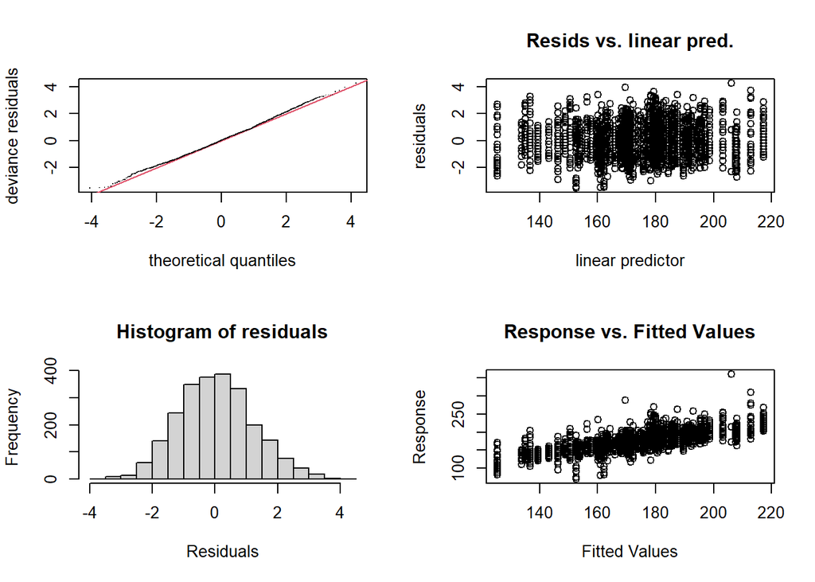

```
##
## Method: fREML   Optimizer: perf chol
## $grad
## [1] -3.106715e-08
##
## $hess
##         [,1]
## [1,] 21.8593
##
## Model rank =  49 / 49
##
## Basis dimension (k) checking results. Low p-value (k-index<1) may
## indicate that k is too low, especially if edf is close to k'.
##
##           k'  edf k-index p-value
## s(subj) 47.0 45.2      NA      NA
```

```r
gam.check(m1scat)
```

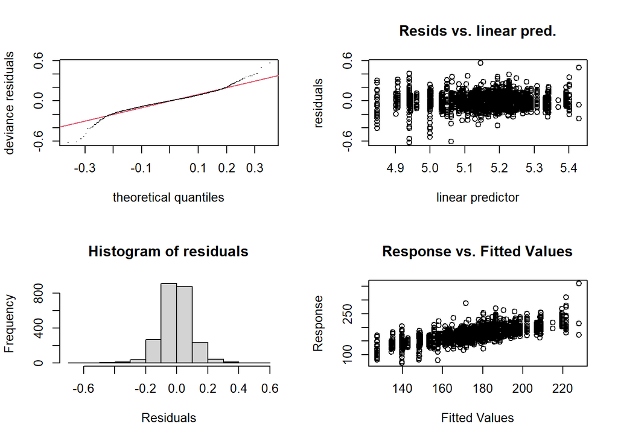

```
##
## Method: fREML   Optimizer: perf newton
## full convergence after 5 iterations.
## Gradient range [-1.684839e-10,4.03233e-11]
## (score -1994.217 & scale 0.01018715).
## Hessian positive definite, eigenvalue range [21.18805,1198.432].
## Model rank =  49 / 49
##
## Basis dimension (k) checking results. Low p-value (k-index<1) may
## indicate that k is too low, especially if edf is close to k'.
##
##           k'  edf k-index p-value
## s(subj) 47.0 45.1      NA      NA
```

```r
gam.check(m1log)
```

SCaled-t looks best.

Add slopes:

```r
summary(m2 <- bam(rightedge.lag ~ onset_type + s(subj, bs='re') + s(subj, onset_type, bs="re"), data=df.nospr, family = "scat", discrete = T))
```

```
##
## Family: Scaled t(3.61,11.739)
## Link function: identity
##
## Formula:
## rightedge.lag ~ onset_type + s(subj, bs = "re") + s(subj, onset_type,
##     bs = "re")
##
## Parametric coefficients:
##                   Estimate Std. Error t value Pr(>|t|)
## (Intercept)        179.453      2.643   67.91   <2e-16 ***
## onset_typecluster   -9.498      1.094   -8.68   <2e-16 ***
## ---
## Signif. codes:  0 '***' 0.001 '**' 0.01 '*' 0.05 '.' 0.1 ' ' 1
##
## Approximate significance of smooth terms:
##                      edf Ref.df       F p-value
## s(subj)            43.79     47 230.978  <2e-16 ***
## s(onset_type,subj) 33.38     94   4.251   0.789
## ---
## Signif. codes:  0 '***' 0.001 '**' 0.01 '*' 0.05 '.' 0.1 ' ' 1
##
## R-sq.(adj) =  0.519   Deviance explained = 44.6%
## fREML = 4105.6  Scale est. = 1         n = 2398
```

No.

Add group:

```r
summary(m1ML <- bam(rightedge.lag ~ onset_type + s(subj, bs='re'), data=df.nospr, method = "ML", family = "scat"))
```

```
##
## Family: Scaled t(3.85,12.303)
## Link function: identity
##
## Formula:
## rightedge.lag ~ onset_type + s(subj, bs = "re")
##
## Parametric coefficients:
##                   Estimate Std. Error t value Pr(>|t|)
## (Intercept)       179.5317     2.5578   70.19   <2e-16 ***
## onset_typecluster  -9.5816     0.5985  -16.01   <2e-16 ***
## ---
## Signif. codes:  0 '***' 0.001 '**' 0.01 '*' 0.05 '.' 0.1 ' ' 1
##
## Approximate significance of smooth terms:
##           edf Ref.df     F p-value
## s(subj) 45.24     46 68.31  <2e-16 ***
## ---
## Signif. codes:  0 '***' 0.001 '**' 0.01 '*' 0.05 '.' 0.1 ' ' 1
##
## R-sq.(adj) =  0.509   Deviance explained = 43.1%
## -ML = 3526.5  Scale est. = 1         n = 2398
```

```r
summary(m3 <- bam(rightedge.lag ~ group + onset_type + s(subj, bs='re'), data=df.nospr, method = "ML", family = "scat"))
```

```
##
## Family: Scaled t(3.85,12.304)
## Link function: identity
##
## Formula:
## rightedge.lag ~ group + onset_type + s(subj, bs = "re")
##
## Parametric coefficients:
##                   Estimate Std. Error t value Pr(>|t|)
## (Intercept)       178.9008     3.6452  49.079   <2e-16 ***
## grouptypical        1.2302     5.0782   0.242    0.809
## onset_typecluster  -9.5811     0.5985 -16.008   <2e-16 ***
## ---
## Signif. codes:  0 '***' 0.001 '**' 0.01 '*' 0.05 '.' 0.1 ' ' 1
##
## Approximate significance of smooth terms:
##           edf Ref.df     F p-value
## s(subj) 44.26     45 69.58  <2e-16 ***
## ---
## Signif. codes:  0 '***' 0.001 '**' 0.01 '*' 0.05 '.' 0.1 ' ' 1
##
## R-sq.(adj) =  0.509   Deviance explained = 43.1%
## -ML = 3526.4  Scale est. = 1         n = 2398
```

```r
compareML(m1ML, m3)
```

```
## m1ML: rightedge.lag ~ onset_type + s(subj, bs = "re")
##
## m3: rightedge.lag ~ group + onset_type + s(subj, bs = "re")
```

```
##
## Chi-square test of ML scores
## -----
##   Model    Score Edf Difference    Df p.value Sig.
## 1  m1ML 3526.466   3
## 2    m3 3526.432   4      0.035 1.000   0.792
##
## AIC difference: -0.06, model m1ML has lower AIC.
```

No.

Add interaction:

```r
summary(mhypo <- bam(rightedge.lag ~ group*onset_type + s(subj, bs='re'), data=df.nospr, method = "ML", family = "scat"))
```

```
##
## Family: Scaled t(3.88,12.311)
## Link function: identity
##
## Formula:
## rightedge.lag ~ group * onset_type + s(subj, bs = "re")
##
## Parametric coefficients:
##                                Estimate Std. Error t value Pr(>|t|)
## (Intercept)                    178.0453     3.6618  48.622  < 2e-16 ***
## grouptypical                     2.8465     5.1173   0.556  0.57809
## onset_typecluster               -7.9055     0.8698  -9.089  < 2e-16 ***
## grouptypical:onset_typecluster  -3.2496     1.1985  -2.711  0.00675 **
## ---
## Signif. codes:  0 '***' 0.001 '**' 0.01 '*' 0.05 '.' 0.1 ' ' 1
##
## Approximate significance of smooth terms:
##           edf Ref.df     F p-value
## s(subj) 44.26     45 69.87  <2e-16 ***
## ---
## Signif. codes:  0 '***' 0.001 '**' 0.01 '*' 0.05 '.' 0.1 ' ' 1
##
## R-sq.(adj) =  0.511   Deviance explained = 43.3%
## -ML = 3526.8  Scale est. = 1         n = 2398
```

```r
compareML(m1ML, mhypo)
```

```
## m1ML: rightedge.lag ~ onset_type + s(subj, bs = "re")
##
## mhypo: rightedge.lag ~ group * onset_type + s(subj, bs = "re")
##
## Model m1ML preferred: lower ML score (0.360), and lower df (2.000).
## -----
##   Model    Score Edf Difference     Df
## 1 mhypo 3526.827   5
## 2  m1ML 3526.466   3      0.360 -2.000
##
## AIC difference: 5.29, model mhypo has lower AIC.
```

Yes.

Fit with REML, since it is the final model:

```r
summary(mhypoREML <- bam(rightedge.lag ~ group*onset_type + s(subj, bs='re'), data=df.nospr, family = "scat"))
```

```
##
## Family: Scaled t(3.88,12.311)
## Link function: identity
##
## Formula:
## rightedge.lag ~ group * onset_type + s(subj, bs = "re")
##
## Parametric coefficients:
##                                Estimate Std. Error t value Pr(>|t|)
## (Intercept)                    178.0554     3.7427  47.575  < 2e-16 ***
## grouptypical                     2.8362     5.2305   0.542  0.58770
## onset_typecluster               -7.9059     0.8698  -9.089  < 2e-16 ***
## grouptypical:onset_typecluster  -3.2504     1.1985  -2.712  0.00673 **
## ---
## Signif. codes:  0 '***' 0.001 '**' 0.01 '*' 0.05 '.' 0.1 ' ' 1
##
## Approximate significance of smooth terms:
##           edf Ref.df     F p-value
## s(subj) 44.29     45 69.93  <2e-16 ***
## ---
## Signif. codes:  0 '***' 0.001 '**' 0.01 '*' 0.05 '.' 0.1 ' ' 1
##
## R-sq.(adj) =  0.511   Deviance explained = 43.3%
## fREML =   3521  Scale est. = 1         n = 2398
```

Check assumptions:

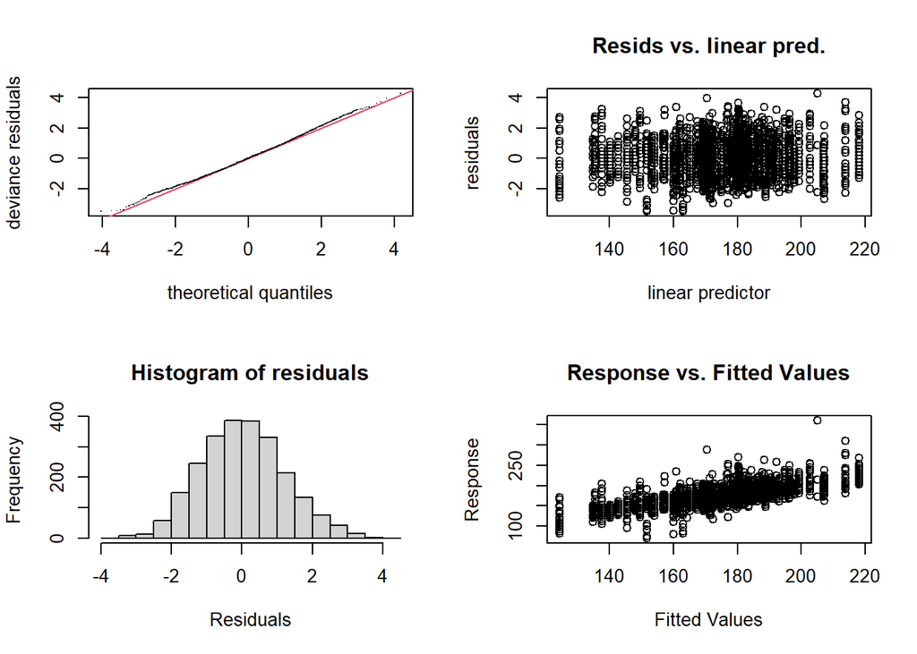

```
##
## Method: fREML   Optimizer: perf newton
## full convergence after 5 iterations.
## Gradient range [2.670747e-06,2.670747e-06]
## (score 3520.963 & scale 1).
## Hessian positive definite, eigenvalue range [21.62708,21.62708].
## Model rank =  51 / 51
##
## Basis dimension (k) checking results. Low p-value (k-index<1) may
## indicate that k is too low, especially if edf is close to k'.
##
##           k'  edf k-index p-value
## s(subj) 47.0 44.3      NA      NA
```

```r
gam.check(mhypoREML)
```

Fine.

Model criticism, trimming:

```r
df.nospr2 <- df.nospr[abs(scale(resid(mhypoREML))) < 2.5, ] # trim model
(1 - (nrow(df.nospr2))/nrow(df.nospr)) * 100
```

```
## [1] 1.59471
```

Refit:

```r
summary(mhypoREML_trim <- bam(rightedge.lag ~ s(subj, bs='re') + onset_type*group, data=df.nospr2, family = "scat"))
```

```
##
## Family: Scaled t(4.016,12.385)
## Link function: identity
##
## Formula:
## rightedge.lag ~ s(subj, bs = "re") + onset_type * group
##
## Parametric coefficients:
##                                Estimate Std. Error t value Pr(>|t|)
## (Intercept)                    178.0524     3.7506  47.473   <2e-16 ***
## onset_typecluster               -7.9017     0.8777  -9.002   <2e-16 ***
## grouptypical                     2.7158     5.2419   0.518   0.6044
## onset_typecluster:grouptypical  -3.0931     1.2111  -2.554   0.0107 *
## ---
## Signif. codes:  0 '***' 0.001 '**' 0.01 '*' 0.05 '.' 0.1 ' ' 1
##
## Approximate significance of smooth terms:
##           edf Ref.df     F p-value
## s(subj) 44.28     45 69.09  <2e-16 ***
## ---
## Signif. codes:  0 '***' 0.001 '**' 0.01 '*' 0.05 '.' 0.1 ' ' 1
##
## R-sq.(adj) =  0.515   Deviance explained = 43.6%
## fREML = 3464.5  Scale est. = 1         n = 2358
```

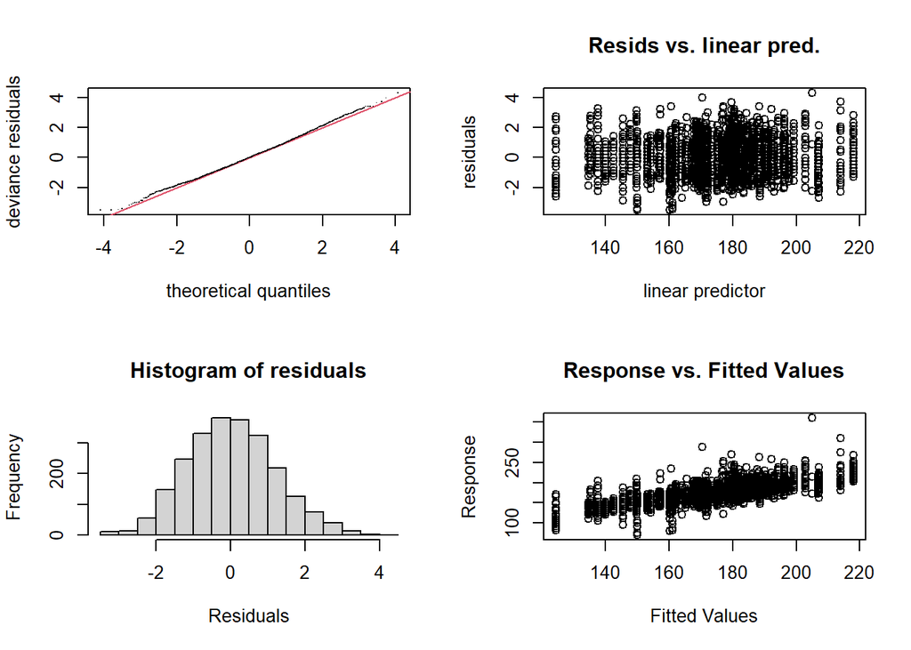

```
##
## Method: fREML   Optimizer: perf newton
## full convergence after 5 iterations.
## Gradient range [4.040382e-06,4.040382e-06]
## (score 3464.475 & scale 1).
## Hessian positive definite, eigenvalue range [21.62128,21.62128].
## Model rank =  51 / 51
##
## Basis dimension (k) checking results. Low p-value (k-index<1) may
## indicate that k is too low, especially if edf is close to k'.
##
##           k'  edf k-index p-value
## s(subj) 47.0 44.3      NA      NA
```

```r
gam.check(mhypoREML_trim)
```

OK.

### 2.2.1 Visualize final model:

```
## Summary:
##  * onset_type : factor; set to the value(s): cluster, singleton.
##  * group : factor; set to the value(s): PD.
##  * subj : factor; set to the value(s): CTRL21. (Might be canceled as random effect, check below.)
##  * NOTE : The following random effects columns are canceled: s(subj)
##
```

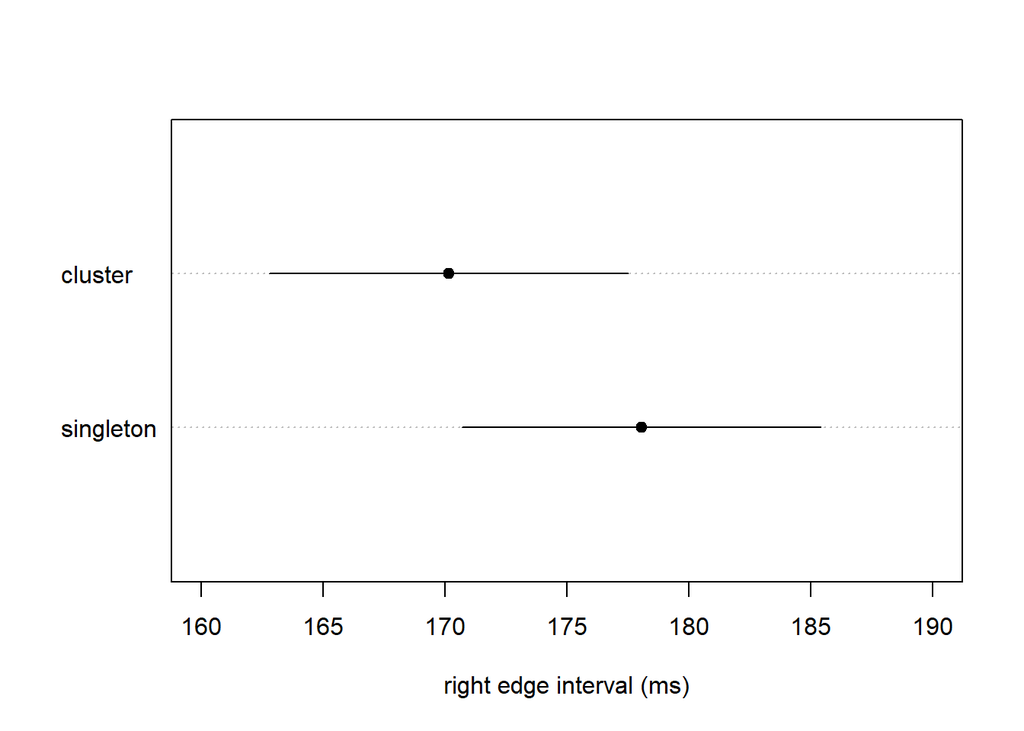

```r
plot_parametric(mhypoREML_trim, cond = list(group= "PD"), pred=list(onset_type = c("singleton", "cluster")), main = "", xlab = "right edge interval (ms)", xlim=c(160,190))
```

```
## Summary:
##  * onset_type : factor; set to the value(s): cluster, singleton.
##  * group : factor; set to the value(s): typical.
##  * subj : factor; set to the value(s): CTRL21. (Might be canceled as random effect, check below.)
##  * NOTE : The following random effects columns are canceled: s(subj)
##
```

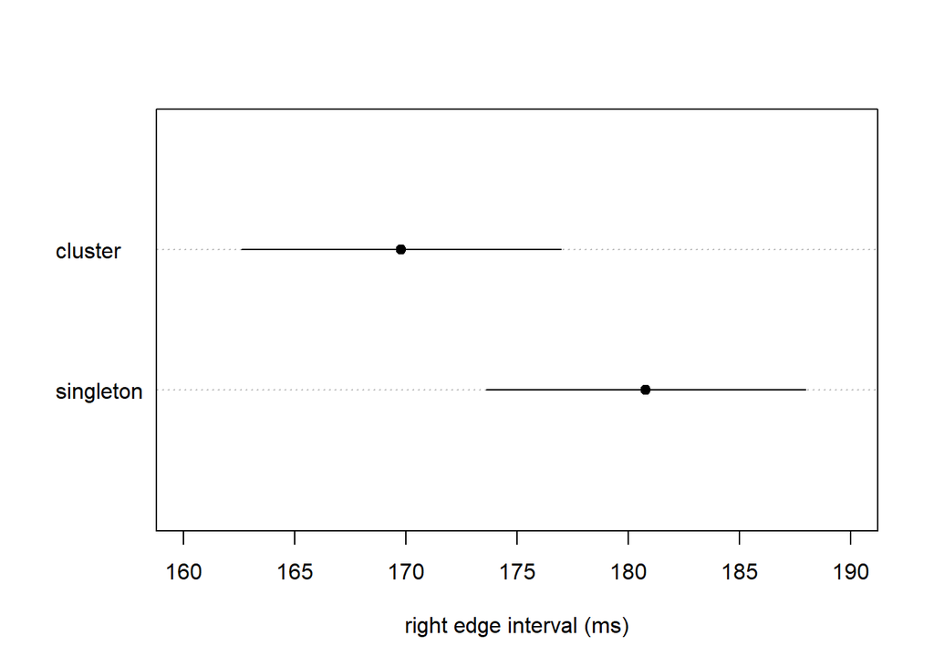

```r
plot_parametric(mhypoREML_trim, cond = list(group= "typical"), pred=list(onset_type = c("singleton", "cluster")), main = "", xlab = "right edge interval (ms)", xlim=c(160,190))
```

## 2.3 Exploratory analysis

Adding item_pair as fixed effect:

```r
summary(m5 <- bam(rightedge.lag ~ s(subj, bs='re') + onset_type*group, data=df.nospr, method = "ML", family = "scat"))
```

```
##
## Family: Scaled t(3.88,12.311)
## Link function: identity
##
## Formula:
## rightedge.lag ~ s(subj, bs = "re") + onset_type * group
##
## Parametric coefficients:
##                                Estimate Std. Error t value Pr(>|t|)
## (Intercept)                    178.0453     3.6618  48.622  < 2e-16 ***
## onset_typecluster               -7.9055     0.8698  -9.089  < 2e-16 ***
## grouptypical                     2.8465     5.1173   0.556  0.57809
## onset_typecluster:grouptypical  -3.2496     1.1985  -2.711  0.00675 **
## ---
## Signif. codes:  0 '***' 0.001 '**' 0.01 '*' 0.05 '.' 0.1 ' ' 1
##
## Approximate significance of smooth terms:
##           edf Ref.df     F p-value
## s(subj) 44.26     45 69.87  <2e-16 ***
## ---
## Signif. codes:  0 '***' 0.001 '**' 0.01 '*' 0.05 '.' 0.1 ' ' 1
##
## R-sq.(adj) =  0.511   Deviance explained = 43.3%
## -ML = 3526.8  Scale est. = 1         n = 2398
```

```r
summary(m6 <- bam(rightedge.lag ~ s(subj, bs='re') + item_pair + onset_type*group, data=df.nospr, method = "ML", family = "scat"))
```

```
##
## Family: Scaled t(3.232,10.929)
## Link function: identity
##
## Formula:
## rightedge.lag ~ s(subj, bs = "re") + item_pair + onset_type *
##     group
##
## Parametric coefficients:
##                                Estimate Std. Error t value Pr(>|t|)
## (Intercept)                    180.8147     3.6221  49.920  < 2e-16 ***
## item_pairsm                     -9.0320     0.6445 -14.014  < 2e-16 ***
## item_pairsx                      3.0820     0.6801   4.531 6.15e-06 ***
## onset_typecluster               -8.2499     0.7893 -10.452  < 2e-16 ***
## grouptypical                     2.5936     5.0392   0.515  0.60683
## onset_typecluster:grouptypical  -2.8410     1.0876  -2.612  0.00905 **
## ---
## Signif. codes:  0 '***' 0.001 '**' 0.01 '*' 0.05 '.' 0.1 ' ' 1
##
## Approximate significance of smooth terms:
##           edf Ref.df     F p-value
## s(subj) 44.37     45 83.02  <2e-16 ***
## ---
## Signif. codes:  0 '***' 0.001 '**' 0.01 '*' 0.05 '.' 0.1 ' ' 1
##
## R-sq.(adj) =   0.54   Deviance explained = 46.2%
## -ML = 3522.6  Scale est. = 1         n = 2398
```

```r
compareML(m5, m6)
```

```
## m5: rightedge.lag ~ s(subj, bs = "re") + onset_type * group
##
## m6: rightedge.lag ~ s(subj, bs = "re") + item_pair + onset_type *
##     group
```

```
##
## Chi-square test of ML scores
## -----
##   Model    Score Edf Difference    Df p.value Sig.
## 1    m5 3526.827   5
## 2    m6 3522.569   7      4.258 2.000   0.014  *
##
## AIC difference: 294.62, model m6 has lower AIC.
```

Yes.

Adding slopes for item_pair:

```r
summary(m7.REML <- bam(rightedge.lag ~ s(subj, bs='re') + item_pair + onset_type*group + s(subj, item_pair, bs="re"), data=df.nospr, method = "fREML", family = "scat", discrete = T))
```

```
##
## Family: Scaled t(3.759,8.896)
## Link function: identity
##
## Formula:
## rightedge.lag ~ s(subj, bs = "re") + item_pair + onset_type *
##     group + s(subj, item_pair, bs = "re")
##
## Parametric coefficients:
##                                Estimate Std. Error t value Pr(>|t|)
## (Intercept)                    180.5607     4.0457  44.630  < 2e-16 ***
## item_pairsm                     -9.4100     2.5507  -3.689  0.00023 ***
## item_pairsx                      1.3542     2.5988   0.521  0.60235
## onset_typecluster               -8.2102     0.6459 -12.712  < 2e-16 ***
## grouptypical                     4.0121     5.2795   0.760  0.44736
## onset_typecluster:grouptypical  -3.7964     0.8937  -4.248 2.25e-05 ***
## ---
## Signif. codes:  0 '***' 0.001 '**' 0.01 '*' 0.05 '.' 0.1 ' ' 1
##
## Approximate significance of smooth terms:
##                     edf Ref.df      F p-value
## s(subj)           37.71     46 2114.0  <2e-16 ***
## s(item_pair,subj) 91.95    139  159.1   0.106
## ---
## Signif. codes:  0 '***' 0.001 '**' 0.01 '*' 0.05 '.' 0.1 ' ' 1
##
## R-sq.(adj) =  0.708   Deviance explained = 60.8%
## fREML = 4228.7  Scale est. = 1         n = 2398
```

No.

Adding onset_type*item_pair as fixed effect:

```r
summary(m7.ML <- bam(rightedge.lag ~  group*onset_type + item_pair + s(subj, bs='re'), data=df.nospr, method = "ML", family = "scat"))
```

```
##
## Family: Scaled t(3.232,10.929)
## Link function: identity
##
## Formula:
## rightedge.lag ~ group * onset_type + item_pair + s(subj, bs = "re")
##
## Parametric coefficients:
##                                Estimate Std. Error t value Pr(>|t|)
## (Intercept)                    180.8147     3.6221  49.920  < 2e-16 ***
## grouptypical                     2.5936     5.0392   0.515  0.60683
## onset_typecluster               -8.2499     0.7893 -10.452  < 2e-16 ***
## item_pairsm                     -9.0320     0.6445 -14.014  < 2e-16 ***
## item_pairsx                      3.0820     0.6801   4.531 6.15e-06 ***
## grouptypical:onset_typecluster  -2.8410     1.0876  -2.612  0.00905 **
## ---
## Signif. codes:  0 '***' 0.001 '**' 0.01 '*' 0.05 '.' 0.1 ' ' 1
##
## Approximate significance of smooth terms:
##           edf Ref.df     F p-value
## s(subj) 44.37     45 83.02  <2e-16 ***
## ---
## Signif. codes:  0 '***' 0.001 '**' 0.01 '*' 0.05 '.' 0.1 ' ' 1
##
## R-sq.(adj) =   0.54   Deviance explained = 46.2%
## -ML = 3522.6  Scale est. = 1         n = 2398
```

```r
summary(m8.ML <- bam(rightedge.lag ~  group*onset_type + onset_type*item_pair + s(subj, bs='re'), data=df.nospr, method = "ML", family = "scat"))
```

```
##
## Family: Scaled t(3.197,10.86)
## Link function: identity
##
## Formula:
## rightedge.lag ~ group * onset_type + onset_type * item_pair +
##     s(subj, bs = "re")
##
## Parametric coefficients:
##                                Estimate Std. Error t value Pr(>|t|)
## (Intercept)                    179.7030     3.6403  49.365  < 2e-16 ***
## grouptypical                     2.5913     5.0402   0.514  0.60721
## onset_typecluster               -6.0977     1.0511  -5.801 7.47e-09 ***
## item_pairsm                     -7.0356     0.9038  -7.785 1.04e-14 ***
## item_pairsx                      4.8888     0.9525   5.133 3.09e-07 ***
## grouptypical:onset_typecluster  -2.6892     1.0823  -2.485  0.01304 *
## onset_typecluster:item_pairsm   -4.0468     1.2822  -3.156  0.00162 **
## onset_typecluster:item_pairsx   -3.6064     1.3441  -2.683  0.00734 **
## ---
## Signif. codes:  0 '***' 0.001 '**' 0.01 '*' 0.05 '.' 0.1 ' ' 1
##
## Approximate significance of smooth terms:
##           edf Ref.df     F p-value
## s(subj) 44.38     45 83.99  <2e-16 ***
## ---
## Signif. codes:  0 '***' 0.001 '**' 0.01 '*' 0.05 '.' 0.1 ' ' 1
##
## R-sq.(adj) =  0.541   Deviance explained = 46.3%
## -ML = 3522.4  Scale est. = 1         n = 2398
```

```r
compareML(m7.ML, m8.ML)
```

```
## m7.ML: rightedge.lag ~ group * onset_type + item_pair + s(subj, bs = "re")
##
## m8.ML: rightedge.lag ~ group * onset_type + onset_type * item_pair +
##     s(subj, bs = "re")
```

```
##
## Chi-square test of ML scores
## -----
##   Model    Score Edf Difference    Df p.value Sig.
## 1 m7.ML 3522.569   7
## 2 m8.ML 3522.401   9      0.168 2.000   0.846
##
## AIC difference: 8.62, model m8.ML has lower AIC.
```

Yes, based on AIC.

Adding item_pair*group as fixed effect:

```r
summary(m9.ML <- bam(rightedge.lag ~  group*onset_type + group*item_pair + onset_type*item_pair + s(subj, bs='re'), data=df.nospr, method = "ML", family = "scat"))
```

```
##
## Family: Scaled t(3.294,10.837)
## Link function: identity
##
## Formula:
## rightedge.lag ~ group * onset_type + group * item_pair + onset_type *
##     item_pair + s(subj, bs = "re")
##
## Parametric coefficients:
##                                Estimate Std. Error t value Pr(>|t|)
## (Intercept)                    180.6520     3.6549  49.427  < 2e-16 ***
## grouptypical                     0.8253     5.0853   0.162  0.87110
## onset_typecluster               -6.1339     1.0451  -5.869 5.01e-09 ***
## item_pairsm                     -6.8665     1.1147  -6.160 8.55e-10 ***
## item_pairsx                     -0.9008     1.1990  -0.751  0.45254
## grouptypical:onset_typecluster  -2.8391     1.0763  -2.638  0.00840 **
## grouptypical:item_pairsm        -0.3809     1.2766  -0.298  0.76547
## grouptypical:item_pairsx        10.4924     1.3497   7.774 1.13e-14 ***
## onset_typecluster:item_pairsm   -3.8959     1.2750  -3.056  0.00227 **
## onset_typecluster:item_pairsx   -3.5027     1.3367  -2.620  0.00884 **
## ---
## Signif. codes:  0 '***' 0.001 '**' 0.01 '*' 0.05 '.' 0.1 ' ' 1
##
## Approximate significance of smooth terms:
##           edf Ref.df     F p-value
## s(subj) 44.38     45 84.78  <2e-16 ***
## ---
## Signif. codes:  0 '***' 0.001 '**' 0.01 '*' 0.05 '.' 0.1 ' ' 1
##
## R-sq.(adj) =  0.548   Deviance explained = 47.3%
## -ML = 3529.9  Scale est. = 1         n = 2398
```

```r
compareML(m8.ML, m9.ML)
```

```
## m8.ML: rightedge.lag ~ group * onset_type + onset_type * item_pair +
##     s(subj, bs = "re")
##
## m9.ML: rightedge.lag ~ group * onset_type + group * item_pair + onset_type *
##     item_pair + s(subj, bs = "re")
##
## Model m8.ML preferred: lower ML score (7.455), and lower df (2.000).
## -----
##   Model    Score Edf Difference     Df
## 1 m9.ML 3529.855  11
## 2 m8.ML 3522.401   9      7.455 -2.000
##
## AIC difference: 54.66, model m9.ML has lower AIC.
```

Yes (based on AIC)

Add three-way interaction:

```r
summary(m9.MLinter <- bam(rightedge.lag ~  group*onset_type*item_pair + s(subj, bs='re'), data=df.nospr, method = "ML", family = "scat"))
```

```
##
## Family: Scaled t(3.286,10.81)
## Link function: identity
##
## Formula:
## rightedge.lag ~ group * onset_type * item_pair + s(subj, bs = "re")
##
## Parametric coefficients:
##                                            Estimate Std. Error t value Pr(>|t|)
## (Intercept)                                180.5158     3.6712  49.171  < 2e-16
## grouptypical                                 1.0665     5.1319   0.208 0.835382
## onset_typecluster                           -5.8827     1.2694  -4.634 3.78e-06
## item_pairsm                                 -7.4285     1.2896  -5.760 9.49e-09
## item_pairsx                                  0.9415     1.3964   0.674 0.500252
## grouptypical:onset_typecluster              -3.3452     1.7700  -1.890 0.058889
## grouptypical:item_pairsm                     0.6517     1.7942   0.363 0.716450
## grouptypical:item_pairsx                     7.1058     1.8972   3.745 0.000184
## onset_typecluster:item_pairsm               -2.7254     1.8401  -1.481 0.138712
## onset_typecluster:item_pairsx               -6.9758     1.9451  -3.586 0.000342
## grouptypical:onset_typecluster:item_pairsm  -2.1249     2.5469  -0.834 0.404186
## grouptypical:onset_typecluster:item_pairsx   6.4199     2.6725   2.402 0.016374
##
## (Intercept)                                ***
## grouptypical
## onset_typecluster                          ***
## item_pairsm                                ***
## item_pairsx
## grouptypical:onset_typecluster             .
## grouptypical:item_pairsm
## grouptypical:item_pairsx                   ***
## onset_typecluster:item_pairsm
## onset_typecluster:item_pairsx              ***
## grouptypical:onset_typecluster:item_pairsm
## grouptypical:onset_typecluster:item_pairsx *
## ---
## Signif. codes:  0 '***' 0.001 '**' 0.01 '*' 0.05 '.' 0.1 ' ' 1
##
## Approximate significance of smooth terms:
##           edf Ref.df     F p-value
## s(subj) 44.39     45 85.04  <2e-16 ***
## ---
## Signif. codes:  0 '***' 0.001 '**' 0.01 '*' 0.05 '.' 0.1 ' ' 1
##
## R-sq.(adj) =  0.547   Deviance explained = 47.3%
## -ML = 3530.9  Scale est. = 1         n = 2398
```

```r
compareML(m9.ML, m9.MLinter)
```

```
## m9.ML: rightedge.lag ~ group * onset_type + group * item_pair + onset_type *
##     item_pair + s(subj, bs = "re")
##
## m9.MLinter: rightedge.lag ~ group * onset_type * item_pair + s(subj, bs = "re")
##
## Model m9.ML preferred: lower ML score (1.086), and lower df (2.000).
## -----
##        Model    Score Edf Difference     Df
## 1 m9.MLinter 3530.942  13
## 2      m9.ML 3529.855  11      1.086 -2.000
##
## AIC difference: 4.13, model m9.MLinter has lower AIC.
```

Yes.

Add speechrate

```r
summary(m10.ML <- bam(rightedge.lag ~  group*onset_type*item_pair + s(duration.tt) + s(subj, bs='re'), data=df.nospr, method = "ML", family = "scat"))
```

```
##
## Family: Scaled t(3.236,10.479)
## Link function: identity
##
## Formula:
## rightedge.lag ~ group * onset_type * item_pair + s(duration.tt) +
##     s(subj, bs = "re")
##
## Parametric coefficients:
##                                            Estimate Std. Error t value Pr(>|t|)
## (Intercept)                                181.8125     3.2153  56.546  < 2e-16
## grouptypical                                -1.1153     4.4957  -0.248 0.804096
## onset_typecluster                           -6.1287     1.2338  -4.967 7.28e-07
## item_pairsm                                 -7.3801     1.2535  -5.888 4.49e-09
## item_pairsx                                  0.4774     1.3574   0.352 0.725058
## grouptypical:onset_typecluster              -2.8809     1.7206  -1.674 0.094191
## grouptypical:item_pairsm                    -0.1386     1.7461  -0.079 0.936744
## grouptypical:item_pairsx                     6.6366     1.8460   3.595 0.000331
## onset_typecluster:item_pairsm               -2.7035     1.7887  -1.511 0.130827
## onset_typecluster:item_pairsx               -5.3554     1.8909  -2.832 0.004663
## grouptypical:onset_typecluster:item_pairsm  -2.5376     2.4773  -1.024 0.305782
## grouptypical:onset_typecluster:item_pairsx   5.8772     2.5988   2.262 0.023818
##
## (Intercept)                                ***
## grouptypical
## onset_typecluster                          ***
## item_pairsm                                ***
## item_pairsx
## grouptypical:onset_typecluster             .
## grouptypical:item_pairsm
## grouptypical:item_pairsx                   ***
## onset_typecluster:item_pairsm
## onset_typecluster:item_pairsx              **
## grouptypical:onset_typecluster:item_pairsm
## grouptypical:onset_typecluster:item_pairsx *
## ---
## Signif. codes:  0 '***' 0.001 '**' 0.01 '*' 0.05 '.' 0.1 ' ' 1
##
## Approximate significance of smooth terms:
##                   edf Ref.df     F p-value
## s(duration.tt)  5.514  6.734 21.18  <2e-16 ***
## s(subj)        44.176 45.000 57.82  <2e-16 ***
## ---
## Signif. codes:  0 '***' 0.001 '**' 0.01 '*' 0.05 '.' 0.1 ' ' 1
##
## R-sq.(adj) =  0.563   Deviance explained = 48.8%
## -ML = 3535.4  Scale est. = 1         n = 2398
```

```r
compareML(m9.ML, m10.ML)
```

```
## m9.ML: rightedge.lag ~ group * onset_type + group * item_pair + onset_type *
##     item_pair + s(subj, bs = "re")
##
## m10.ML: rightedge.lag ~ group * onset_type * item_pair + s(duration.tt) +
##     s(subj, bs = "re")
##
## Model m9.ML preferred: lower ML score (5.569), and lower df (4.000).
## -----
##    Model    Score Edf Difference     Df
## 1 m10.ML 3535.424  15
## 2  m9.ML 3529.855  11      5.569 -4.000
##
## AIC difference: 116.48, model m10.ML has lower AIC.
```

Yes, since AIC difference is larger than 2.

Add random smooth.

```r
summary(m11 <- bam(rightedge.lag ~ group*onset_type*item_pair + s(duration.tt) +  s(duration.tt, subj, bs="fs", m=1), data=df.nospr, method = "fREML", family = "scat", discrete=T, nthreads = 2))
```

```
##
## Family: Scaled t(3,9.968)
## Link function: identity
##
## Formula:
## rightedge.lag ~ group * onset_type * item_pair + s(duration.tt) +
##     s(duration.tt, subj, bs = "fs", m = 1)
##
## Parametric coefficients:
##                                            Estimate Std. Error t value Pr(>|t|)
## (Intercept)                                183.7708     3.2592  56.386  < 2e-16
## grouptypical                                -1.9318     4.4664  -0.433 0.665405
## onset_typecluster                           -6.0793     1.1182  -5.437  6.0e-08
## item_pairsm                                 -7.8059     1.1858  -6.583  5.7e-11
## item_pairsx                                 -0.7814     1.5349  -0.509 0.610744
## grouptypical:onset_typecluster              -2.8210     1.5750  -1.791 0.073406
## grouptypical:item_pairsm                     0.4376     1.6196   0.270 0.787057
## grouptypical:item_pairsx                     7.8759     2.0815   3.784 0.000158
## onset_typecluster:item_pairsm               -3.0585     1.6562  -1.847 0.064925
## onset_typecluster:item_pairsx               -4.9069     2.0403  -2.405 0.016251
## grouptypical:onset_typecluster:item_pairsm  -2.4304     2.2878  -1.062 0.288208
## grouptypical:onset_typecluster:item_pairsx   5.3775     2.8253   1.903 0.057121
##
## (Intercept)                                ***
## grouptypical
## onset_typecluster                          ***
## item_pairsm                                ***
## item_pairsx
## grouptypical:onset_typecluster             .
## grouptypical:item_pairsm
## grouptypical:item_pairsx                   ***
## onset_typecluster:item_pairsm              .
## onset_typecluster:item_pairsx              *
## grouptypical:onset_typecluster:item_pairsm
## grouptypical:onset_typecluster:item_pairsx .
## ---
## Signif. codes:  0 '***' 0.001 '**' 0.01 '*' 0.05 '.' 0.1 ' ' 1
##
## Approximate significance of smooth terms:
##                        edf  Ref.df      F p-value
## s(duration.tt)       5.469   6.438 13.707  <2e-16 ***
## s(duration.tt,subj) 83.761 291.000  9.214   0.921
## ---
## Signif. codes:  0 '***' 0.001 '**' 0.01 '*' 0.05 '.' 0.1 ' ' 1
##
## R-sq.(adj) =  0.566   Deviance explained = 49.6%
## fREML =   4215  Scale est. = 1         n = 2398
```

Random smooth is not required.

Separate for group?

```r
summary(m12 <- bam(rightedge.lag ~ group*onset_type*item_pair + s(duration.tt) + s(duration.tt, by = IsTP), data=df.nospr, method = "fREML", family = "scat", discrete=T, nthreads = 2))
```

```
##
## Family: Scaled t(4.634,15.81)
## Link function: identity
##
## Formula:
## rightedge.lag ~ group * onset_type * item_pair + s(duration.tt) +
##     s(duration.tt, by = IsTP)
##
## Parametric coefficients:
##                                            Estimate Std. Error t value Pr(>|t|)
## (Intercept)                                184.9236     1.5880 116.449  < 2e-16
## grouptypical                                 0.0000     0.0000     NaN      NaN
## onset_typecluster                           -4.9876     1.7556  -2.841 0.004535
## item_pairsm                                 -6.4634     1.7840  -3.623 0.000297
## item_pairsx                                  2.4772     2.0073   1.234 0.217302
## grouptypical:onset_typecluster              -4.4208     2.4476  -1.806 0.071019
## grouptypical:item_pairsm                    -0.1673     2.4618  -0.068 0.945814
## grouptypical:item_pairsx                     5.5882     2.7739   2.015 0.044064
## onset_typecluster:item_pairsm               -3.4805     2.5559  -1.362 0.173409
## onset_typecluster:item_pairsx               -6.2893     2.8103  -2.238 0.025316
## grouptypical:onset_typecluster:item_pairsm  -1.2524     3.5039  -0.357 0.720792
## grouptypical:onset_typecluster:item_pairsx   9.4667     3.8812   2.439 0.014796
##
## (Intercept)                                ***
## grouptypical
## onset_typecluster                          **
## item_pairsm                                ***
## item_pairsx
## grouptypical:onset_typecluster             .
## grouptypical:item_pairsm
## grouptypical:item_pairsx                   *
## onset_typecluster:item_pairsm
## onset_typecluster:item_pairsx              *
## grouptypical:onset_typecluster:item_pairsm
## grouptypical:onset_typecluster:item_pairsx *
## ---
## Signif. codes:  0 '***' 0.001 '**' 0.01 '*' 0.05 '.' 0.1 ' ' 1
##
## Approximate significance of smooth terms:
##                       edf Ref.df      F p-value
## s(duration.tt)      7.038  7.927 50.476  <2e-16 ***
## s(duration.tt):IsTP 7.058  8.080  8.732  <2e-16 ***
## ---
## Signif. codes:  0 '***' 0.001 '**' 0.01 '*' 0.05 '.' 0.1 ' ' 1
##
## Rank: 30/31
## R-sq.(adj) =  0.302   Deviance explained = 26.4%
## fREML = 3821.5  Scale est. = 1         n = 2398
```

Yes.

Add appropriate random smmooths:

```r
summary(m12sm <- bam(rightedge.lag ~ group*onset_type*item_pair + s(duration.tt) + s(duration.tt, by = IsTP)+ s(duration.tt, subj, bs="fs", m=1) +  s(duration.tt, subj, by = IsTP, bs="fs", m=1), data=df.nospr, method = "fREML", family = "scat", discrete=T, nthreads = 2))
```

```
##
## Family: Scaled t(3.047,10.006)
## Link function: identity
##
## Formula:
## rightedge.lag ~ group * onset_type * item_pair + s(duration.tt) +
##     s(duration.tt, by = IsTP) + s(duration.tt, subj, bs = "fs",
##     m = 1) + s(duration.tt, subj, by = IsTP, bs = "fs", m = 1)
##
## Parametric coefficients:
##                                            Estimate Std. Error t value Pr(>|t|)
## (Intercept)                                183.8294     3.3091  55.552  < 2e-16
## grouptypical                                -2.0130     4.5423  -0.443 0.657679
## onset_typecluster                           -6.0739     1.1209  -5.419 6.63e-08
## item_pairsm                                 -7.8158     1.1878  -6.580 5.81e-11
## item_pairsx                                 -0.8008     1.5352  -0.522 0.601988
## grouptypical:onset_typecluster              -2.8354     1.5785  -1.796 0.072588
## grouptypical:item_pairsm                     0.4556     1.6233   0.281 0.779006
## grouptypical:item_pairsx                     7.9075     2.0831   3.796 0.000151
## onset_typecluster:item_pairsm               -3.0573     1.6597  -1.842 0.065597
## onset_typecluster:item_pairsx               -4.8883     2.0412  -2.395 0.016708
## grouptypical:onset_typecluster:item_pairsm  -2.4308     2.2925  -1.060 0.289098
## grouptypical:onset_typecluster:item_pairsx   5.3606     2.8284   1.895 0.058184
##
## (Intercept)                                ***
## grouptypical
## onset_typecluster                          ***
## item_pairsm                                ***
## item_pairsx
## grouptypical:onset_typecluster             .
## grouptypical:item_pairsm
## grouptypical:item_pairsx                   ***
## onset_typecluster:item_pairsm              .
## onset_typecluster:item_pairsx              *
## grouptypical:onset_typecluster:item_pairsm
## grouptypical:onset_typecluster:item_pairsx .
## ---
## Signif. codes:  0 '***' 0.001 '**' 0.01 '*' 0.05 '.' 0.1 ' ' 1
##
## Approximate significance of smooth terms:
##                                edf  Ref.df      F p-value
## s(duration.tt)            5.457047   6.426 10.849  <2e-16 ***
## s(duration.tt):IsTP       1.000033   1.000  0.010   0.922
## s(duration.tt,subj)      83.690309 324.000  8.272   0.283
## s(duration.tt,subj):IsTP  0.003868 188.000  0.000  <2e-16 ***
## ---
## Signif. codes:  0 '***' 0.001 '**' 0.01 '*' 0.05 '.' 0.1 ' ' 1
##
## Rank: 876/877
## R-sq.(adj) =  0.566   Deviance explained = 49.8%
## fREML = 4205.9  Scale est. = 1         n = 2398
```

We need the smooths, but group diff. becomes non-sign.

Add recording.no (check using select =T):

```r
summary(m11.alt <- bam(rightedge.lag ~  group*onset_type*item_pair + s(duration.tt) + s(subj, bs = "re"), data=df.nospr, method = "fREML", family = "scat", select = T, discrete=T, nthreads = 2))
```

```
##
## Family: Scaled t(3.238,10.479)
## Link function: identity
##
## Formula:
## rightedge.lag ~ group * onset_type * item_pair + s(duration.tt) +
##     s(subj, bs = "re")
##
## Parametric coefficients:
##                                             Estimate Std. Error t value
## (Intercept)                                183.51790    3.31611  55.341
## grouptypical                                -1.13679    4.58328  -0.248
## onset_typecluster                           -6.14916    1.16186  -5.293
## item_pairsm                                 -7.43113    1.21008  -6.141
## item_pairsx                                  0.43964    1.54765   0.284
## grouptypical:onset_typecluster              -2.85385    1.61679  -1.765
## grouptypical:item_pairsm                    -0.05003    1.65594  -0.030
## grouptypical:item_pairsx                     6.66744    2.09057   3.189
## onset_typecluster:item_pairsm               -2.65265    1.71246  -1.549
## onset_typecluster:item_pairsx               -5.36255    2.08346  -2.574
## grouptypical:onset_typecluster:item_pairsm  -2.63347    2.35835  -1.117
## grouptypical:onset_typecluster:item_pairsx   5.90122    2.86054   2.063
##                                            Pr(>|t|)
## (Intercept)                                 < 2e-16 ***
## grouptypical                                0.80413
## onset_typecluster                          1.32e-07 ***
## item_pairsm                                9.61e-10 ***
## item_pairsx                                 0.77638
## grouptypical:onset_typecluster              0.07767 .
## grouptypical:item_pairsm                    0.97590
## grouptypical:item_pairsx                    0.00145 **
## onset_typecluster:item_pairsm               0.12151
## onset_typecluster:item_pairsx               0.01012 *
## grouptypical:onset_typecluster:item_pairsm  0.26426
## grouptypical:onset_typecluster:item_pairsx  0.03923 *
## ---
## Signif. codes:  0 '***' 0.001 '**' 0.01 '*' 0.05 '.' 0.1 ' ' 1
##
## Approximate significance of smooth terms:
##                   edf Ref.df      F p-value
## s(duration.tt)  5.516      9 2152.0  <2e-16 ***
## s(subj)        44.124     45   54.2  <2e-16 ***
## ---
## Signif. codes:  0 '***' 0.001 '**' 0.01 '*' 0.05 '.' 0.1 ' ' 1
##
## R-sq.(adj) =  0.563   Deviance explained = 48.8%
## fREML = 4123.3  Scale est. = 1         n = 2398
```

```r
summary(m13.alt <- bam(rightedge.lag ~  group*onset_type*item_pair + s(duration.tt) + s(recording.no) + s(subj, bs = "re"), data=df.nospr, method = "fREML", family = "scat", select= T, discrete=T, nthreads = 2))
```

```
##
## Family: Scaled t(3.205,10.408)
## Link function: identity
##
## Formula:
## rightedge.lag ~ group * onset_type * item_pair + s(duration.tt) +
##     s(recording.no) + s(subj, bs = "re")
##
## Parametric coefficients:
##                                              Estimate Std. Error t value
## (Intercept)                                183.023149   3.361799  54.442
## grouptypical                                -0.896560   4.645312  -0.193
## onset_typecluster                           -6.146073   1.155623  -5.318
## item_pairsm                                 -7.452901   1.200222  -6.210
## item_pairsx                                  0.379692   1.544346   0.246
## grouptypical:onset_typecluster              -2.914307   1.605366  -1.815
## grouptypical:item_pairsm                     0.002255   1.643624   0.001
## grouptypical:item_pairsx                     6.785866   2.083664   3.257
## onset_typecluster:item_pairsm               -2.523553   1.704032  -1.481
## onset_typecluster:item_pairsx               -5.397560   2.080286  -2.595
## grouptypical:onset_typecluster:item_pairsm  -2.725692   2.344418  -1.163
## grouptypical:onset_typecluster:item_pairsx   5.943077   2.853357   2.083
##                                            Pr(>|t|)
## (Intercept)                                 < 2e-16 ***
## grouptypical                                0.84697
## onset_typecluster                          1.15e-07 ***
## item_pairsm                                6.27e-10 ***
## item_pairsx                                 0.80581
## grouptypical:onset_typecluster              0.06960 .
## grouptypical:item_pairsm                    0.99891
## grouptypical:item_pairsx                    0.00114 **
## onset_typecluster:item_pairsm               0.13876
## onset_typecluster:item_pairsx               0.00953 **
## grouptypical:onset_typecluster:item_pairsm  0.24510
## grouptypical:onset_typecluster:item_pairsx  0.03737 *
## ---
## Signif. codes:  0 '***' 0.001 '**' 0.01 '*' 0.05 '.' 0.1 ' ' 1
##
## Approximate significance of smooth terms:
##                    edf Ref.df        F  p-value
## s(duration.tt)   5.483      9 1746.446  < 2e-16 ***
## s(recording.no)  1.723      9    4.182 0.000255 ***
## s(subj)         44.151     45   55.203  < 2e-16 ***
## ---
## Signif. codes:  0 '***' 0.001 '**' 0.01 '*' 0.05 '.' 0.1 ' ' 1
##
## R-sq.(adj) =  0.563   Deviance explained = 48.9%
## fREML = 4133.6  Scale est. = 1         n = 2398
```

```r
compareML(m11.alt, m13.alt)
```

```
## m11.alt: rightedge.lag ~ group * onset_type * item_pair + s(duration.tt) +
##     s(subj, bs = "re")
##
## m13.alt: rightedge.lag ~ group * onset_type * item_pair + s(duration.tt) +
##     s(recording.no) + s(subj, bs = "re")
##
## Model m11.alt preferred: lower fREML score (10.259), and lower df (2.000).
## -----
##     Model    Score Edf Difference     Df
## 1 m13.alt 4133.566  17
## 2 m11.alt 4123.307  15     10.259 -2.000
##
## AIC difference: 13.52, model m13.alt has lower AIC.
```

Yes (based on AIC).

Add random smooth:

```r
summary(m14 <- bam(rightedge.lag ~ group*onset_type*item_pair + s(duration.tt) + s(recording.no) + s(recording.no, subj, bs="fs", m=1), data=df.nospr, method = "fREML", family = "scat", discrete=T, nthreads = 2))
```

```
##
## Family: Scaled t(3,9.803)
## Link function: identity
##
## Formula:
## rightedge.lag ~ group * onset_type * item_pair + s(duration.tt) +
##     s(recording.no) + s(recording.no, subj, bs = "fs", m = 1)
##
## Parametric coefficients:
##                                            Estimate Std. Error t value Pr(>|t|)
## (Intercept)                                182.7329     3.3534  54.492  < 2e-16
## grouptypical                                -0.8557     4.6278  -0.185 0.853321
## onset_typecluster                           -6.1270     1.0956  -5.592 2.51e-08
## item_pairsm                                 -7.5431     1.1487  -6.567 6.35e-11
## item_pairsx                                  0.2018     1.4951   0.135 0.892655
## grouptypical:onset_typecluster              -2.9587     1.5269  -1.938 0.052779
## grouptypical:item_pairsm                     0.1743     1.5728   0.111 0.911764
## grouptypical:item_pairsx                     7.3566     2.0313   3.622 0.000299
## onset_typecluster:item_pairsm               -2.5602     1.6212  -1.579 0.114432
## onset_typecluster:item_pairsx               -4.9381     2.0135  -2.453 0.014258
## grouptypical:onset_typecluster:item_pairsm  -2.7473     2.2361  -1.229 0.219331
## grouptypical:onset_typecluster:item_pairsx   5.1915     2.7702   1.874 0.061053
##
## (Intercept)                                ***
## grouptypical
## onset_typecluster                          ***
## item_pairsm                                ***
## item_pairsx
## grouptypical:onset_typecluster             .
## grouptypical:item_pairsm
## grouptypical:item_pairsx                   ***
## onset_typecluster:item_pairsm
## onset_typecluster:item_pairsx              *
## grouptypical:onset_typecluster:item_pairsm
## grouptypical:onset_typecluster:item_pairsx .
## ---
## Signif. codes:  0 '***' 0.001 '**' 0.01 '*' 0.05 '.' 0.1 ' ' 1
##
## Approximate significance of smooth terms:
##                          edf  Ref.df      F p-value
## s(duration.tt)         5.764   6.943 13.711  <2e-16 ***
## s(recording.no)        1.000   1.000  3.944  0.0472 *
## s(recording.no,subj) 102.243 409.000  7.004  <2e-16 ***
## ---
## Signif. codes:  0 '***' 0.001 '**' 0.01 '*' 0.05 '.' 0.1 ' ' 1
##
## R-sq.(adj) =  0.566   Deviance explained = 50.3%
## fREML = 4249.6  Scale est. = 1         n = 2398
```

We need the smooth.

Check group difference:

```r
summary(m15 <- bam(rightedge.lag ~ group*onset_type*item_pair + s(duration.tt) + s(recording.no) + s(recording.no, by = IsTP) + s(recording.no, subj, bs="fs", m=1), data=df.nospr, method = "fREML", family = "scat", discrete=T, nthreads = 2))
```

```
##
## Family: Scaled t(3,9.797)
## Link function: identity
##
## Formula:
## rightedge.lag ~ group * onset_type * item_pair + s(duration.tt) +
##     s(recording.no) + s(recording.no, by = IsTP) + s(recording.no,
##     subj, bs = "fs", m = 1)
##
## Parametric coefficients:
##                                            Estimate Std. Error t value Pr(>|t|)
## (Intercept)                                182.7881     3.3526  54.522  < 2e-16
## grouptypical                                -0.2595     4.7516  -0.055 0.956444
## onset_typecluster                           -6.1306     1.0951  -5.598 2.43e-08
## item_pairsm                                 -7.5514     1.1486  -6.574 6.04e-11
## item_pairsx                                  0.2108     1.4947   0.141 0.887856
## grouptypical:onset_typecluster              -2.9691     1.5261  -1.945 0.051839
## grouptypical:item_pairsm                     0.1645     1.5722   0.105 0.916696
## grouptypical:item_pairsx                     7.3367     2.0298   3.614 0.000308
## onset_typecluster:item_pairsm               -2.5612     1.6205  -1.581 0.114120
## onset_typecluster:item_pairsx               -4.9425     2.0125  -2.456 0.014131
## grouptypical:onset_typecluster:item_pairsm  -2.7148     2.2351  -1.215 0.224645
## grouptypical:onset_typecluster:item_pairsx   5.2360     2.7691   1.891 0.058765
##
## (Intercept)                                ***
## grouptypical
## onset_typecluster                          ***
## item_pairsm                                ***
## item_pairsx
## grouptypical:onset_typecluster             .
## grouptypical:item_pairsm
## grouptypical:item_pairsx                   ***
## onset_typecluster:item_pairsm
## onset_typecluster:item_pairsx              *
## grouptypical:onset_typecluster:item_pairsm
## grouptypical:onset_typecluster:item_pairsx .
## ---
## Signif. codes:  0 '***' 0.001 '**' 0.01 '*' 0.05 '.' 0.1 ' ' 1
##
## Approximate significance of smooth terms:
##                          edf  Ref.df      F p-value
## s(duration.tt)         5.760   6.941 13.756  <2e-16 ***
## s(recording.no)        1.000   1.000  1.219    0.27
## s(recording.no):IsTP   1.515   1.782  0.369    0.75
## s(recording.no,subj) 101.900 409.000  7.003  <2e-16 ***
## ---
## Signif. codes:  0 '***' 0.001 '**' 0.01 '*' 0.05 '.' 0.1 ' ' 1
##
## Rank: 462/463
## R-sq.(adj) =  0.566   Deviance explained = 50.3%
## fREML = 4249.3  Scale est. = 1         n = 2398
```

No group difference.

Add gender (using select = T)?

```r
summary(m14.alt <- bam(rightedge.lag ~ group*onset_type*item_pair + s(duration.tt) + s(recording.no) + s(recording.no, subj, bs="fs", m=1), data=df.nospr, method = "fREML", family = "scat", select = T, discrete=T, nthreads = 2))
```

```
##
## Family: Scaled t(3,9.798)
## Link function: identity
##
## Formula:
## rightedge.lag ~ group * onset_type * item_pair + s(duration.tt) +
##     s(recording.no) + s(recording.no, subj, bs = "fs", m = 1)
##
## Parametric coefficients:
##                                            Estimate Std. Error t value Pr(>|t|)
## (Intercept)                                182.8727     3.3546  54.514  < 2e-16
## grouptypical                                -0.9016     4.6306  -0.195 0.845646
## onset_typecluster                           -6.1490     1.0954  -5.614 2.22e-08
## item_pairsm                                 -7.5944     1.1490  -6.610 4.78e-11
## item_pairsx                                  0.2015     1.4947   0.135 0.892769
## grouptypical:onset_typecluster              -2.9087     1.5263  -1.906 0.056813
## grouptypical:item_pairsm                     0.2538     1.5721   0.161 0.871759
## grouptypical:item_pairsx                     7.3420     2.0302   3.616 0.000305
## onset_typecluster:item_pairsm               -2.5112     1.6207  -1.549 0.121422
## onset_typecluster:item_pairsx               -4.9904     2.0134  -2.479 0.013263
## grouptypical:onset_typecluster:item_pairsm  -2.8564     2.2345  -1.278 0.201260
## grouptypical:onset_typecluster:item_pairsx   5.2487     2.7699   1.895 0.058234
##
## (Intercept)                                ***
## grouptypical
## onset_typecluster                          ***
## item_pairsm                                ***
## item_pairsx
## grouptypical:onset_typecluster             .
## grouptypical:item_pairsm
## grouptypical:item_pairsx                   ***
## onset_typecluster:item_pairsm
## onset_typecluster:item_pairsx              *
## grouptypical:onset_typecluster:item_pairsm
## grouptypical:onset_typecluster:item_pairsx .
## ---
## Signif. codes:  0 '***' 0.001 '**' 0.01 '*' 0.05 '.' 0.1 ' ' 1
##
## Approximate significance of smooth terms:
##                          edf Ref.df      F p-value
## s(duration.tt)         5.562      9 10.809 < 2e-16 ***
## s(recording.no)        1.315      9  0.426 0.00267 **
## s(recording.no,subj) 102.441    409  7.048 < 2e-16 ***
## ---
## Signif. codes:  0 '***' 0.001 '**' 0.01 '*' 0.05 '.' 0.1 ' ' 1
##
## R-sq.(adj) =  0.566   Deviance explained = 50.3%
## fREML = 4255.5  Scale est. = 1         n = 2398
```

```r
summary(m16.alt <- bam(rightedge.lag ~ group*onset_type*item_pair + s(duration.tt) + gender + s(recording.no) + s(recording.no, subj, bs="fs", m=1), data=df.nospr, method = "fREML", family = "scat", select = T, discrete=T, nthreads = 2))
```

```
##
## Family: Scaled t(3,9.798)
## Link function: identity
##
## Formula:
## rightedge.lag ~ group * onset_type * item_pair + s(duration.tt) +
##     gender + s(recording.no) + s(recording.no, subj, bs = "fs",
##     m = 1)
##
## Parametric coefficients:
##                                            Estimate Std. Error t value Pr(>|t|)
## (Intercept)                                191.2306     5.0518  37.854  < 2e-16
## grouptypical                                -1.6465     4.4766  -0.368 0.713049
## onset_typecluster                           -6.1475     1.0952  -5.613 2.23e-08
## item_pairsm                                 -7.5934     1.1487  -6.610 4.76e-11
## item_pairsx                                  0.2085     1.4943   0.140 0.889047
## genderM                                    -10.7967     5.0166  -2.152 0.031488
## grouptypical:onset_typecluster              -2.9110     1.5263  -1.907 0.056618
## grouptypical:item_pairsm                     0.2527     1.5718   0.161 0.872307
## grouptypical:item_pairsx                     7.3379     2.0296   3.615 0.000306
## onset_typecluster:item_pairsm               -2.5159     1.6207  -1.552 0.120728
## onset_typecluster:item_pairsx               -4.9980     2.0129  -2.483 0.013100
## grouptypical:onset_typecluster:item_pairsm  -2.8549     2.2346  -1.278 0.201526
## grouptypical:onset_typecluster:item_pairsx   5.2542     2.7693   1.897 0.057915
##
## (Intercept)                                ***
## grouptypical
## onset_typecluster                          ***
## item_pairsm                                ***
## item_pairsx
## genderM                                    *
## grouptypical:onset_typecluster             .
## grouptypical:item_pairsm
## grouptypical:item_pairsx                   ***
## onset_typecluster:item_pairsm
## onset_typecluster:item_pairsx              *
## grouptypical:onset_typecluster:item_pairsm
## grouptypical:onset_typecluster:item_pairsx .
## ---
## Signif. codes:  0 '***' 0.001 '**' 0.01 '*' 0.05 '.' 0.1 ' ' 1
##
## Approximate significance of smooth terms:
##                          edf Ref.df      F p-value
## s(duration.tt)         5.542      9 10.653 < 2e-16 ***
## s(recording.no)        1.332      9  0.440 0.00239 **
## s(recording.no,subj) 101.289    409  6.639 < 2e-16 ***
## ---
## Signif. codes:  0 '***' 0.001 '**' 0.01 '*' 0.05 '.' 0.1 ' ' 1
##
## R-sq.(adj) =  0.566   Deviance explained = 50.3%
## fREML = 4250.6  Scale est. = 1         n = 2398
```

```r
compareML(m14.alt, m16.alt)
```

```
## m14.alt: rightedge.lag ~ group * onset_type * item_pair + s(duration.tt) +
##     s(recording.no) + s(recording.no, subj, bs = "fs", m = 1)
##
## m16.alt: rightedge.lag ~ group * onset_type * item_pair + s(duration.tt) +
##     gender + s(recording.no) + s(recording.no, subj, bs = "fs",
##     m = 1)
```

```
##
## Chi-square test of fREML scores
## -----
##     Model    Score Edf Difference    Df p.value Sig.
## 1 m14.alt 4255.533  18
## 2 m16.alt 4250.633  19      4.900 1.000   0.002  **
##
## AIC difference: -0.03, model m14.alt has lower AIC.
```

No, AIC diff is only 0.03.

Interaction with group?

```r
summary(m17.alt <- bam(rightedge.lag ~ group*onset_type*item_pair + s(duration.tt) + group*gender + s(recording.no) + s(recording.no, subj, bs="fs", m=1), data=df.nospr, method = "fREML", family = "scat", select = T, discrete=T, nthreads = 2))
```

```
##
## Family: Scaled t(3,9.798)
## Link function: identity
##
## Formula:
## rightedge.lag ~ group * onset_type * item_pair + s(duration.tt) +
##     group * gender + s(recording.no) + s(recording.no, subj,
##     bs = "fs", m = 1)
##
## Parametric coefficients:
##                                            Estimate Std. Error t value Pr(>|t|)
## (Intercept)                                187.4525     6.7445  27.793  < 2e-16
## grouptypical                                 4.8130     8.8324   0.545 0.585855
## onset_typecluster                           -6.1461     1.0953  -5.611 2.25e-08
## item_pairsm                                 -7.5904     1.1488  -6.607 4.86e-11
## item_pairsx                                  0.2088     1.4943   0.140 0.888900
## genderM                                     -5.9969     7.5692  -0.792 0.428285
## grouptypical:onset_typecluster              -2.9136     1.5264  -1.909 0.056414
## grouptypical:item_pairsm                     0.2497     1.5719   0.159 0.873805
## grouptypical:item_pairsx                     7.3366     2.0296   3.615 0.000307
## onset_typecluster:item_pairsm               -2.5165     1.6208  -1.553 0.120640
## onset_typecluster:item_pairsx               -5.0034     2.0132  -2.485 0.013015
## grouptypical:genderM                        -8.6179    10.1417  -0.850 0.395555
## grouptypical:onset_typecluster:item_pairsm  -2.8561     2.2347  -1.278 0.201357
## grouptypical:onset_typecluster:item_pairsx   5.2597     2.7695   1.899 0.057671
##
## (Intercept)                                ***
## grouptypical
## onset_typecluster                          ***
## item_pairsm                                ***
## item_pairsx
## genderM
## grouptypical:onset_typecluster             .
## grouptypical:item_pairsm
## grouptypical:item_pairsx                   ***
## onset_typecluster:item_pairsm
## onset_typecluster:item_pairsx              *
## grouptypical:genderM
## grouptypical:onset_typecluster:item_pairsm
## grouptypical:onset_typecluster:item_pairsx .
## ---
## Signif. codes:  0 '***' 0.001 '**' 0.01 '*' 0.05 '.' 0.1 ' ' 1
##
## Approximate significance of smooth terms:
##                          edf Ref.df      F p-value
## s(duration.tt)         5.556      9 10.591 < 2e-16 ***
## s(recording.no)        1.338      9  0.445 0.00229 **
## s(recording.no,subj) 100.349    407  6.672 < 2e-16 ***
## ---
## Signif. codes:  0 '***' 0.001 '**' 0.01 '*' 0.05 '.' 0.1 ' ' 1
##
## R-sq.(adj) =  0.566   Deviance explained = 50.3%
## fREML = 4247.1  Scale est. = 1         n = 2398
```

```r
compareML(m14.alt, m17.alt)
```

```
## m14.alt: rightedge.lag ~ group * onset_type * item_pair + s(duration.tt) +
##     s(recording.no) + s(recording.no, subj, bs = "fs", m = 1)
##
## m17.alt: rightedge.lag ~ group * onset_type * item_pair + s(duration.tt) +
##     group * gender + s(recording.no) + s(recording.no, subj,
##     bs = "fs", m = 1)
```

```
##
## Chi-square test of fREML scores
## -----
##     Model    Score Edf Difference    Df   p.value Sig.
## 1 m14.alt 4255.533  18
## 2 m17.alt 4247.056  20      8.477 2.000 2.082e-04  ***
##
## AIC difference: 0.15, model m17.alt has lower AIC.
```

No, AIC diff is only 0.15.

Add age

```r
summary(m18.alt <- bam(rightedge.lag ~ group*onset_type*item_pair + s(age) + s(duration.tt) + s(recording.no) + s(recording.no, subj, bs="fs", m=1), data=df.nospr, method = "fREML", family = "scat", select = T, discrete=T, nthreads = 2))
```

```
##
## Family: Scaled t(3,9.797)
## Link function: identity
##
## Formula:
## rightedge.lag ~ group * onset_type * item_pair + s(age) + s(duration.tt) +
##     s(recording.no) + s(recording.no, subj, bs = "fs", m = 1)
##
## Parametric coefficients:
##                                            Estimate Std. Error t value Pr(>|t|)
## (Intercept)                                182.8421     3.3525  54.540  < 2e-16
## grouptypical                                -0.9195     4.6268  -0.199 0.842487
## onset_typecluster                           -6.1489     1.0952  -5.614 2.22e-08
## item_pairsm                                 -7.5940     1.1489  -6.610 4.78e-11
## item_pairsx                                  0.2019     1.4947   0.135 0.892550
## grouptypical:onset_typecluster              -2.9095     1.5262  -1.906 0.056734
## grouptypical:item_pairsm                     0.2533     1.5720   0.161 0.872025
## grouptypical:item_pairsx                     7.3419     2.0301   3.617 0.000305
## onset_typecluster:item_pairsm               -2.5123     1.6206  -1.550 0.121225
## onset_typecluster:item_pairsx               -4.9901     2.0133  -2.479 0.013264
## grouptypical:onset_typecluster:item_pairsm  -2.8547     2.2344  -1.278 0.201503
## grouptypical:onset_typecluster:item_pairsx   5.2495     2.7698   1.895 0.058187
##
## (Intercept)                                ***
## grouptypical
## onset_typecluster                          ***
## item_pairsm                                ***
## item_pairsx
## grouptypical:onset_typecluster             .
## grouptypical:item_pairsm
## grouptypical:item_pairsx                   ***
## onset_typecluster:item_pairsm
## onset_typecluster:item_pairsx              *
## grouptypical:onset_typecluster:item_pairsm
## grouptypical:onset_typecluster:item_pairsx .
## ---
## Signif. codes:  0 '***' 0.001 '**' 0.01 '*' 0.05 '.' 0.1 ' ' 1
##
## Approximate significance of smooth terms:
##                            edf Ref.df      F p-value
## s(age)               2.698e-03      9  0.000 < 2e-16 ***
## s(duration.tt)       5.562e+00      9 10.814 < 2e-16 ***
## s(recording.no)      1.315e+00      9  0.425 0.00267 **
## s(recording.no,subj) 1.025e+02    409  7.035 < 2e-16 ***
## ---
## Signif. codes:  0 '***' 0.001 '**' 0.01 '*' 0.05 '.' 0.1 ' ' 1
##
## R-sq.(adj) =  0.566   Deviance explained = 50.3%
## fREML = 4255.6  Scale est. = 1         n = 2398
```

```r
compareML(m14.alt, m18.alt)
```

```
## m14.alt: rightedge.lag ~ group * onset_type * item_pair + s(duration.tt) +
##     s(recording.no) + s(recording.no, subj, bs = "fs", m = 1)
##
## m18.alt: rightedge.lag ~ group * onset_type * item_pair + s(age) + s(duration.tt) +
##     s(recording.no) + s(recording.no, subj, bs = "fs", m = 1)
##
## Model m14.alt preferred: lower fREML score (0.089), and lower df (2.000).
## -----
##     Model    Score Edf Difference     Df
## 1 m18.alt 4255.622  20
## 2 m14.alt 4255.533  18      0.089 -2.000
##
## AIC difference: 0.04, model m18.alt has lower AIC.
```

No, AIC diff. is 0.04.

Interaction with group?

```r
summary(m19 <- bam(rightedge.lag ~  group*onset_type*item_pair + s(age) + s(age, by = IsTP) + s(duration.tt) + s(recording.no) + s(recording.no, subj, bs="fs", m=1), data=df.nospr, method = "fREML", family = "scat", discrete=T, nthreads = 2))
```

```
##
## Family: Scaled t(3,9.804)
## Link function: identity
##
## Formula:
## rightedge.lag ~ group * onset_type * item_pair + s(age) + s(age,
##     by = IsTP) + s(duration.tt) + s(recording.no) + s(recording.no,
##     subj, bs = "fs", m = 1)
##
## Parametric coefficients:
##                                            Estimate Std. Error t value Pr(>|t|)
## (Intercept)                                182.5996     3.3739  54.121  < 2e-16
## grouptypical                                 0.0000     0.0000     NaN      NaN
## onset_typecluster                           -6.1266     1.0958  -5.591 2.53e-08
## item_pairsm                                 -7.5412     1.1488  -6.565 6.44e-11
## item_pairsx                                  0.2022     1.4950   0.135 0.892448
## grouptypical:onset_typecluster              -2.9626     1.5271  -1.940 0.052509
## grouptypical:item_pairsm                     0.1747     1.5730   0.111 0.911574
## grouptypical:item_pairsx                     7.3566     2.0308   3.623 0.000298
## onset_typecluster:item_pairsm               -2.5608     1.6214  -1.579 0.114379
## onset_typecluster:item_pairsx               -4.9365     2.0134  -2.452 0.014288
## grouptypical:onset_typecluster:item_pairsm  -2.7504     2.2364  -1.230 0.218895
## grouptypical:onset_typecluster:item_pairsx   5.1676     2.7700   1.866 0.062236
##
## (Intercept)                                ***
## grouptypical
## onset_typecluster                          ***
## item_pairsm                                ***
## item_pairsx
## grouptypical:onset_typecluster             .
## grouptypical:item_pairsm
## grouptypical:item_pairsx                   ***
## onset_typecluster:item_pairsm
## onset_typecluster:item_pairsx              *
## grouptypical:onset_typecluster:item_pairsm
## grouptypical:onset_typecluster:item_pairsx .
## ---
## Signif. codes:  0 '***' 0.001 '**' 0.01 '*' 0.05 '.' 0.1 ' ' 1
##
## Approximate significance of smooth terms:
##                          edf  Ref.df      F p-value
## s(age)                 1.000   1.000  0.055  0.8143
## s(age):IsTP            2.000   2.000  1.081  0.3393
## s(duration.tt)         5.776   6.955 13.670  <2e-16 ***
## s(recording.no)        1.000   1.000  4.005  0.0455 *
## s(recording.no,subj) 100.269 407.000  6.593  <2e-16 ***
## ---
## Signif. codes:  0 '***' 0.001 '**' 0.01 '*' 0.05 '.' 0.1 ' ' 1
##
## Rank: 471/472
## R-sq.(adj) =  0.566   Deviance explained = 50.3%
## fREML = 4242.5  Scale est. = 1         n = 2398
```

No.

As a constant effect (using select =T)?

```r
summary(m20.alt <- bam(rightedge.lag ~  group*onset_type*item_pair + age*group + s(duration.tt) + s(recording.no) + s(recording.no, subj, bs="fs", m=1), data=df.nospr, method = "fREML", family = "scat", select = T, discrete=T, nthreads = 2))
```

```
##
## Family: Scaled t(3,9.798)
## Link function: identity
##
## Formula:
## rightedge.lag ~ group * onset_type * item_pair + age * group +
##     s(duration.tt) + s(recording.no) + s(recording.no, subj,
##     bs = "fs", m = 1)
##
## Parametric coefficients:
##                                            Estimate Std. Error t value Pr(>|t|)
## (Intercept)                                175.1320    32.8772   5.327 1.10e-07
## grouptypical                                67.4577    48.2766   1.397 0.162455
## onset_typecluster                           -6.1486     1.0955  -5.613 2.24e-08
## item_pairsm                                 -7.5925     1.1491  -6.608 4.85e-11
## item_pairsx                                  0.2023     1.4947   0.135 0.892326
## age                                          0.1111     0.4715   0.236 0.813748
## grouptypical:onset_typecluster              -2.9124     1.5266  -1.908 0.056541
## grouptypical:item_pairsm                     0.2541     1.5722   0.162 0.871621
## grouptypical:item_pairsx                     7.3424     2.0298   3.617 0.000304
## onset_typecluster:item_pairsm               -2.5120     1.6208  -1.550 0.121326
## onset_typecluster:item_pairsx               -4.9891     2.0134  -2.478 0.013285
## grouptypical:age                            -1.0030     0.7002  -1.432 0.152170
## grouptypical:onset_typecluster:item_pairsm  -2.8593     2.2349  -1.279 0.200888
## grouptypical:onset_typecluster:item_pairsx   5.2248     2.7698   1.886 0.059373
##
## (Intercept)                                ***
## grouptypical
## onset_typecluster                          ***
## item_pairsm                                ***
## item_pairsx
## age
## grouptypical:onset_typecluster             .
## grouptypical:item_pairsm
## grouptypical:item_pairsx                   ***
## onset_typecluster:item_pairsm
## onset_typecluster:item_pairsx              *
## grouptypical:age
## grouptypical:onset_typecluster:item_pairsm
## grouptypical:onset_typecluster:item_pairsx .
## ---
## Signif. codes:  0 '***' 0.001 '**' 0.01 '*' 0.05 '.' 0.1 ' ' 1
##
## Approximate significance of smooth terms:
##                          edf Ref.df      F p-value
## s(duration.tt)         5.577      9 10.791  <2e-16 ***
## s(recording.no)        1.326      9  0.434  0.0025 **
## s(recording.no,subj) 100.427    407  6.644  <2e-16 ***
## ---
## Signif. codes:  0 '***' 0.001 '**' 0.01 '*' 0.05 '.' 0.1 ' ' 1
##
## R-sq.(adj) =  0.566   Deviance explained = 50.3%
## fREML = 4253.4  Scale est. = 1         n = 2398
```

```r
compareML(m14.alt, m20.alt)
```

```
## m14.alt: rightedge.lag ~ group * onset_type * item_pair + s(duration.tt) +
##     s(recording.no) + s(recording.no, subj, bs = "fs", m = 1)
##
## m20.alt: rightedge.lag ~ group * onset_type * item_pair + age * group +
##     s(duration.tt) + s(recording.no) + s(recording.no, subj,
##     bs = "fs", m = 1)
```

```
##
## Chi-square test of fREML scores
## -----
##     Model    Score Edf Difference    Df p.value Sig.
## 1 m14.alt 4255.533  18
## 2 m20.alt 4253.446  20      2.087 2.000   0.124
##
## AIC difference: 0.10, model m20.alt has lower AIC.
```

### 2.3.1 Checking assumptions

Final model:

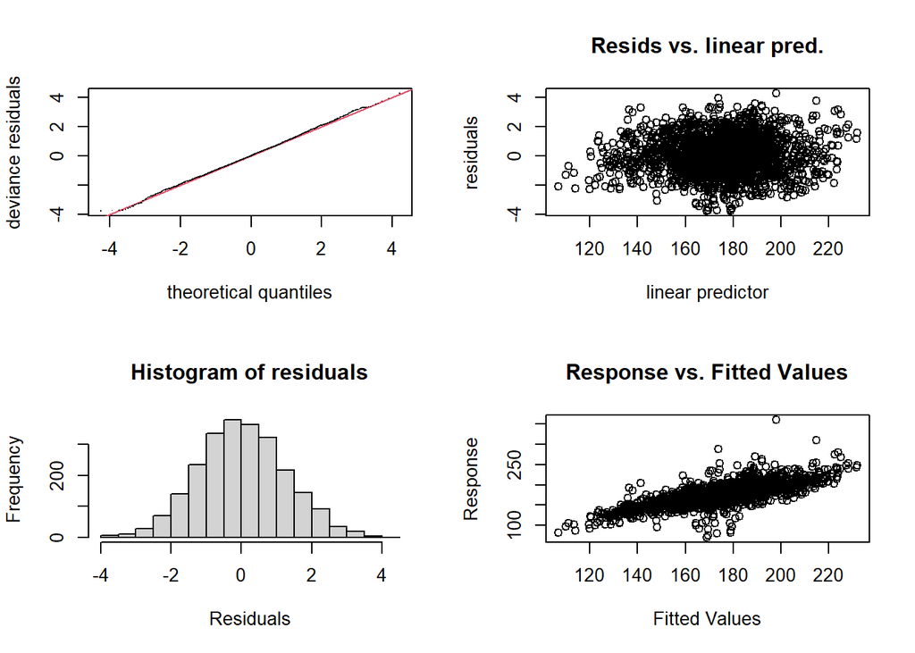

```
##
## Method: fREML   Optimizer: perf chol
## $grad
## [1]  1.126738e-07 -2.210905e-05  5.673249e-07 -6.591246e-08
##
## $hess
##               [,1]          [,2]          [,3]         [,4]
## [1,]  1.622739e+00  6.556960e-07 -6.963006e-02 1.700447e-02
## [2,]  6.556960e-07  2.210742e-05 -8.111652e-06 8.968498e-07
## [3,] -6.963006e-02 -8.111652e-06  1.189850e+01 5.481146e-02
## [4,]  1.700447e-02  8.968498e-07  5.481146e-02 2.115119e+01
##
## Model rank =  453 / 453
##
## Basis dimension (k) checking results. Low p-value (k-index<1) may
## indicate that k is too low, especially if edf is close to k'.
##
##                          k'    edf k-index p-value
## s(duration.tt)         9.00   5.76    1.01    0.71
## s(recording.no)        9.00   1.00    1.06    1.00
## s(recording.no,subj) 423.00 102.24    1.06    1.00
```

```r
mFinal <- m14
gam.check(mFinal)
```

Looks excellent.

Model criticism, trimming:

```r
df.nospr3 <- df.nospr[abs(scale(resid(mFinal))) < 2.5, ] # trim model
(1 - (nrow(df.nospr3))/nrow(df.nospr)) * 100
```

```
## [1] 1.59471
```

1.6% removed.

Refit:

```r
summary(mFinal_trim <- bam(rightedge.lag ~ group*onset_type*item_pair + s(duration.tt) + s(recording.no) + s(recording.no, subj, bs="fs", m=1), data=df.nospr3, method = "fREML", family = "scat", discrete=T, nthreads = 2))
```

```
##
## Family: Scaled t(3,9.808)
## Link function: identity
##
## Formula:
## rightedge.lag ~ group * onset_type * item_pair + s(duration.tt) +
##     s(recording.no) + s(recording.no, subj, bs = "fs", m = 1)
##
## Parametric coefficients:
##                                            Estimate Std. Error t value Pr(>|t|)
## (Intercept)                                182.7139     3.3532  54.489  < 2e-16
## grouptypical                                -0.9072     4.6303  -0.196 0.844689
## onset_typecluster                           -6.0881     1.1004  -5.533 3.52e-08
## item_pairsm                                 -7.6274     1.1523  -6.619 4.51e-11
## item_pairsx                                  0.2096     1.5443   0.136 0.892042
## grouptypical:onset_typecluster              -2.8666     1.5401  -1.861 0.062835
## grouptypical:item_pairsm                     0.4226     1.5859   0.266 0.789902
## grouptypical:item_pairsx                     7.1981     2.0728   3.473 0.000525
## onset_typecluster:item_pairsm               -2.4794     1.6341  -1.517 0.129346
## onset_typecluster:item_pairsx               -5.1078     2.0470  -2.495 0.012660
## grouptypical:onset_typecluster:item_pairsm  -2.9925     2.2567  -1.326 0.184968
## grouptypical:onset_typecluster:item_pairsx   5.3955     2.8029   1.925 0.054361
##
## (Intercept)                                ***
## grouptypical
## onset_typecluster                          ***
## item_pairsm                                ***
## item_pairsx
## grouptypical:onset_typecluster             .
## grouptypical:item_pairsm
## grouptypical:item_pairsx                   ***
## onset_typecluster:item_pairsm
## onset_typecluster:item_pairsx              *
## grouptypical:onset_typecluster:item_pairsm
## grouptypical:onset_typecluster:item_pairsx .
## ---
## Signif. codes:  0 '***' 0.001 '**' 0.01 '*' 0.05 '.' 0.1 ' ' 1
##
## Approximate significance of smooth terms:
##                         edf  Ref.df      F p-value
## s(duration.tt)        5.668   6.849 13.358  <2e-16 ***
## s(recording.no)       1.000   1.000  4.301  0.0382 *
## s(recording.no,subj) 99.575 409.000  6.865  <2e-16 ***
## ---
## Signif. codes:  0 '***' 0.001 '**' 0.01 '*' 0.05 '.' 0.1 ' ' 1
##
## R-sq.(adj) =  0.568   Deviance explained = 50.3%
## fREML = 4172.1  Scale est. = 1         n = 2359
```

OK.

Visualize:

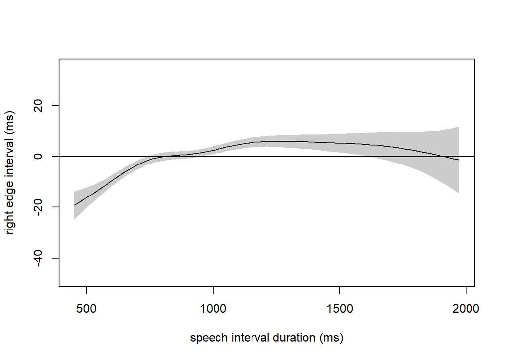

```r
plot(mFinal_trim, select = 1, shade = T, rug = F, ylab = "right edge interval (ms)", xlab="speech interval duration (ms)")
abline(h=0)
```

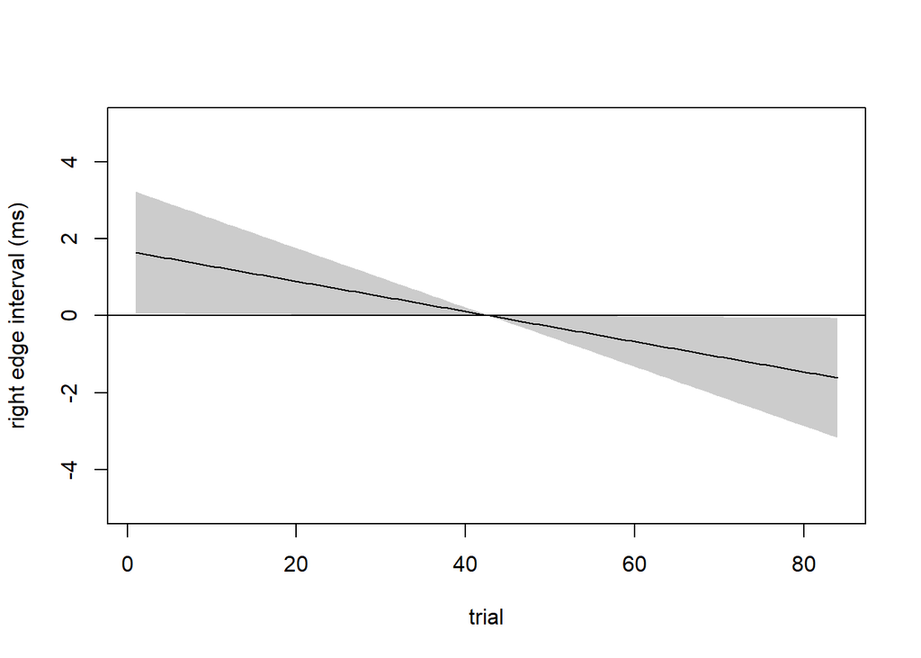

```r
plot(mFinal_trim, select = 2, shade = T, rug = F, ylab = "right edge interval (ms)", xlab="trial", ylim =c(-5,5))
abline(h=0)
```

```
## Summary:
##  * group : factor; set to the value(s): PD.
##  * onset_type : factor; set to the value(s): cluster, singleton.
##  * item_pair : factor; set to the value(s): sp.
##  * duration.tt : numeric predictor; set to the value(s): 795.
##  * recording.no : numeric predictor; set to the value(s): 38.
##  * subj : factor; set to the value(s): CTRL21. (Might be canceled as random effect, check below.)
##  * NOTE : The following random effects columns are canceled: s(recording.no,subj)
##
```

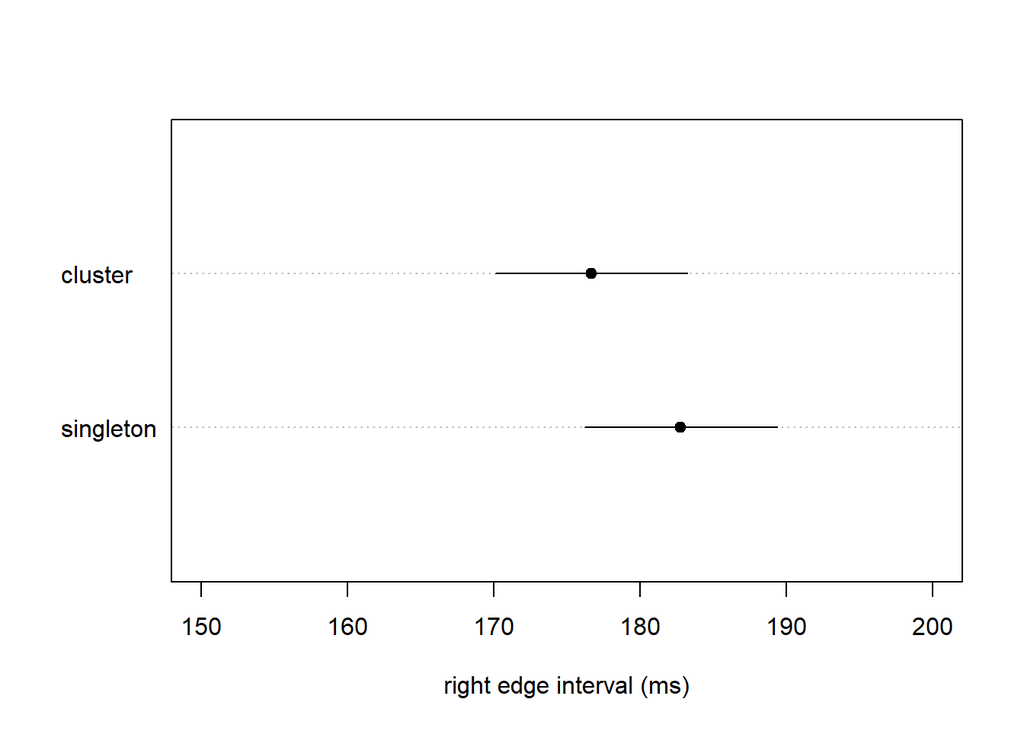

```r
plot_parametric(mFinal_trim, cond = list(group= "PD", item_pair = "sp"), pred=list(onset_type = c("singleton", "cluster")), main = "", xlab = "right edge interval (ms)", xlim=c(150, 200))
```

```
## Summary:
##  * group : factor; set to the value(s): PD.
##  * onset_type : factor; set to the value(s): cluster, singleton.
##  * item_pair : factor; set to the value(s): sm.
##  * duration.tt : numeric predictor; set to the value(s): 795.
##  * recording.no : numeric predictor; set to the value(s): 38.
##  * subj : factor; set to the value(s): CTRL21. (Might be canceled as random effect, check below.)
##  * NOTE : The following random effects columns are canceled: s(recording.no,subj)
##
```

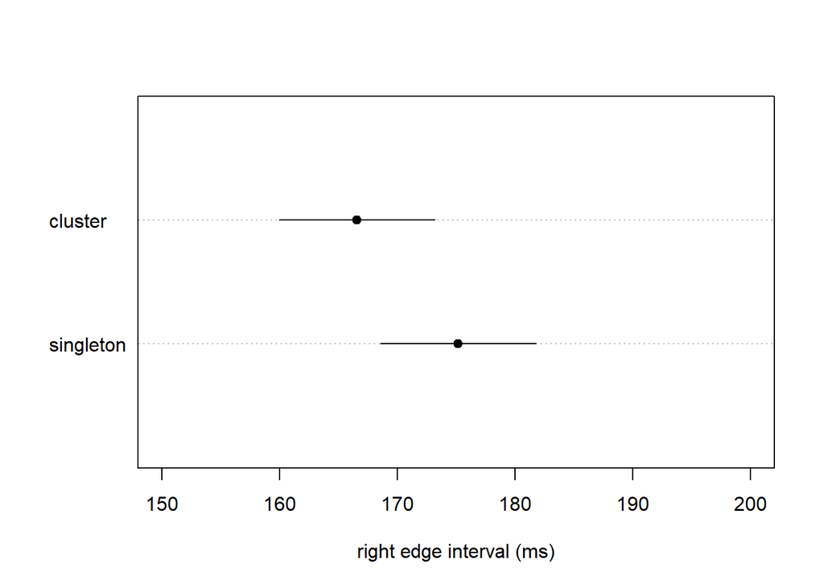

```r
plot_parametric(mFinal_trim, cond = list(group= "PD", item_pair = "sm"), pred=list(onset_type = c("singleton", "cluster")), main = "", xlab = "right edge interval (ms)", xlim=c(150, 200))
```

```
## Summary:
##  * group : factor; set to the value(s): PD.
##  * onset_type : factor; set to the value(s): cluster, singleton.
##  * item_pair : factor; set to the value(s): sx.
##  * duration.tt : numeric predictor; set to the value(s): 795.
##  * recording.no : numeric predictor; set to the value(s): 38.
##  * subj : factor; set to the value(s): CTRL21. (Might be canceled as random effect, check below.)
##  * NOTE : The following random effects columns are canceled: s(recording.no,subj)
##
```

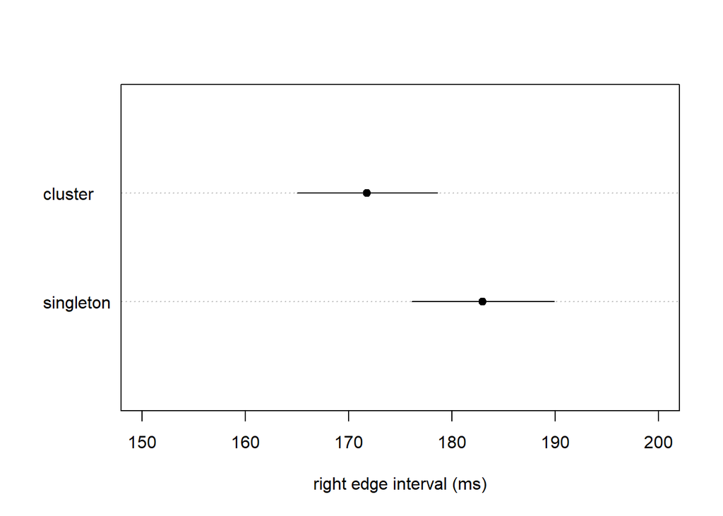

```r
plot_parametric(mFinal_trim, cond = list(group= "PD", item_pair = "sx"), pred=list(onset_type = c("singleton", "cluster")), main = "", xlab = "right edge interval (ms)", xlim=c(150, 200))
```

```
## Summary:
##  * group : factor; set to the value(s): typical.
##  * onset_type : factor; set to the value(s): cluster, singleton.
##  * item_pair : factor; set to the value(s): sp.
##  * duration.tt : numeric predictor; set to the value(s): 795.
##  * recording.no : numeric predictor; set to the value(s): 38.
##  * subj : factor; set to the value(s): CTRL21. (Might be canceled as random effect, check below.)
##  * NOTE : The following random effects columns are canceled: s(recording.no,subj)
##
```

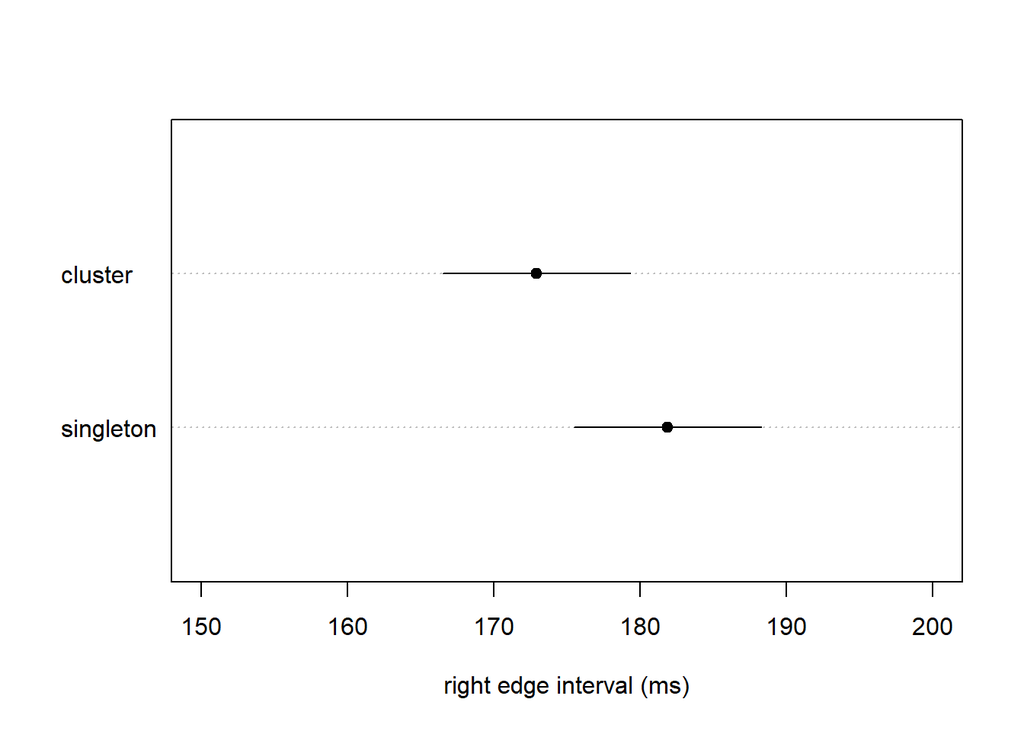

```r
plot_parametric(mFinal_trim, cond = list(group= "typical", item_pair = "sp"), pred=list(onset_type = c("singleton", "cluster")), main = "", xlab = "right edge interval (ms)", xlim=c(150, 200))
```

```
## Summary:
##  * group : factor; set to the value(s): typical.
##  * onset_type : factor; set to the value(s): cluster, singleton.
##  * item_pair : factor; set to the value(s): sm.
##  * duration.tt : numeric predictor; set to the value(s): 795.
##  * recording.no : numeric predictor; set to the value(s): 38.
##  * subj : factor; set to the value(s): CTRL21. (Might be canceled as random effect, check below.)
##  * NOTE : The following random effects columns are canceled: s(recording.no,subj)
##
```

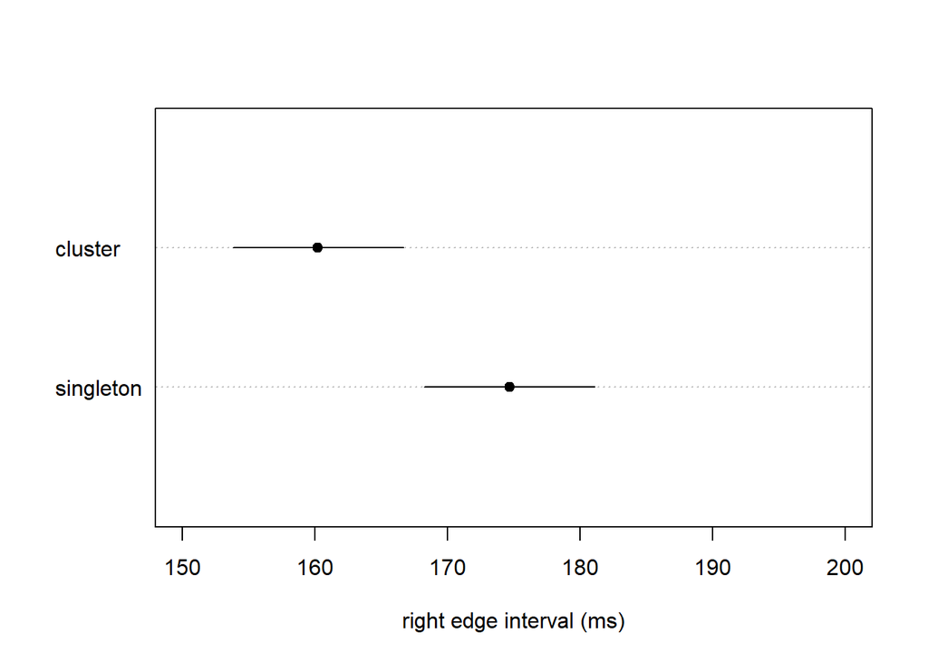

```r
plot_parametric(mFinal_trim, cond = list(group= "typical", item_pair = "sm"), pred=list(onset_type = c("singleton", "cluster")), main = "", xlab = "right edge interval (ms)", xlim=c(150, 200))
```

```
## Summary:
##  * group : factor; set to the value(s): typical.
##  * onset_type : factor; set to the value(s): cluster, singleton.
##  * item_pair : factor; set to the value(s): sx.
##  * duration.tt : numeric predictor; set to the value(s): 795.
##  * recording.no : numeric predictor; set to the value(s): 38.
##  * subj : factor; set to the value(s): CTRL21. (Might be canceled as random effect, check below.)
##  * NOTE : The following random effects columns are canceled: s(recording.no,subj)
##
```

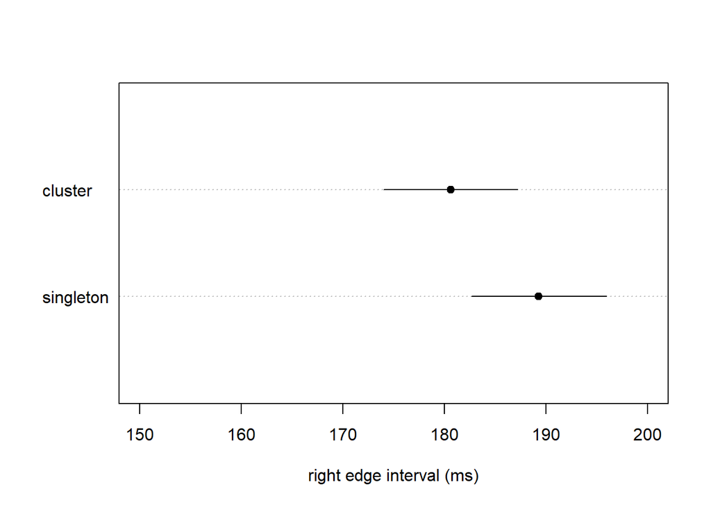

```r
plot_parametric(mFinal_trim, cond = list(group= "typical", item_pair = "sx"), pred=list(onset_type = c("singleton", "cluster")), main = "", xlab = "right edge interval (ms)", xlim=c(150, 200))
```

# 3 Latex table

Latex table function:

```r
gamtabs2 <- function (model, caption = " ", label = "tab.gam",
    pnames = NA, snames = NA, ptab = NA, stab = NA, ...)
{
    if (!requireNamespace("xtable", quietly = TRUE)) {
        stop("Package 'xtable' needed for this function to work. Please install it.",
            call. = FALSE)
    }
    sum.gam <- model
    if (!inherits(model, "summary.gam")) {
        sum.gam <- summary(model)
    }
    if (is.na(ptab[1])) {
        ptab = as.data.frame(sum.gam$p.table, stringsAsFactors = FALSE)
    }
    if (is.na(stab[1])) {
        stab = as.data.frame(sum.gam$s.table, stringsAsFactors = FALSE)
    }
    if (!is.na(pnames[1])) {
        rownames(ptab) = pnames
    }
    if (!is.na(snames[1])) {
        rownames(stab) = snames
    }
    colnames(ptab)[4] = "p-value"
    colnames(ptab)[3] = "t-value"
    ptab.cnames = colnames(ptab)
    stab.cnames = colnames(stab)
    stab.cnames[3] = "F-value"
    colnames(ptab) = c("A", "B", "C", "D")
    if (ncol(stab) != 0) {
        colnames(stab) = colnames(ptab)
    }
    tab = rbind(ptab, stab)
    colnames(tab) = ptab.cnames
    tab = round(tab, 4)
    m = data.frame(matrix(0, nrow(tab), ncol(tab)), stringsAsFactors = FALSE)
    for (i in 1:nrow(tab)) {
        for (j in 1:4) {
            if ((j == 4) & (tab[i, j] < 1e-03)) {
                m[i, j] = "< 0.001"
            }
            else {
                m[i, j] = sprintf("%3.3f", tab[i, j])
            }
        }
    }
    colnames(m) = colnames(tab)
    rownames(m) = rownames(tab)
    tab = m
    tab2 = rbind(c(ptab.cnames), tab[1:nrow(ptab), ])
    if (nrow(stab) > 0) {
        tab2 = rbind(tab2, c(stab.cnames), tab[(nrow(ptab) +
            1):nrow(tab), ])
    }
    if (nrow(stab)) {
        rownames(tab2)[(nrow(ptab) + 2)] = "B. smooth terms"
    }
    rownames(tab2)[1] = "A. parametric coefficients"
    for (i in 1:nrow(tab2)) {
        if (tab2[i, 4] == "0")
            tab2[i, 4] = "< 0.0001"
        if (length(grep("\\.", tab2[i, 2])) == 0)
            tab2[i, 2] = paste(tab2[i, 2], ".0000", sep = "")
    }
    print(xtable::xtable(tab2, caption = caption, label = label,
        align = "lrrrr"), include.colnames = FALSE, hline.after = c(0,
        (nrow(ptab) + 1), nrow(tab2)), ...)
}
```

Latex table:

```r
options(xtable.comment = FALSE)
gamtabs2(mFinal_trim)
```

```
## \begin{table}[ht]
## \centering
## \begin{tabular}{lrrrr}
##    \hline
## A. parametric coefficients & Estimate & Std. Error & t-value & p-value \\
##   (Intercept) & 182.714 & 3.353 & 54.489 & $<$ 0.001 \\
##   grouptypical & -0.907 & 4.630 & -0.196 & 0.845 \\
##   onset\_typecluster & -6.088 & 1.100 & -5.533 & $<$ 0.001 \\
##   item\_pairsm & -7.627 & 1.152 & -6.619 & $<$ 0.001 \\
##   item\_pairsx & 0.210 & 1.544 & 0.136 & 0.892 \\
##   grouptypical:onset\_typecluster & -2.867 & 1.540 & -1.861 & 0.063 \\
##   grouptypical:item\_pairsm & 0.423 & 1.586 & 0.267 & 0.790 \\
##   grouptypical:item\_pairsx & 7.198 & 2.073 & 3.473 & $<$ 0.001 \\
##   onset\_typecluster:item\_pairsm & -2.479 & 1.634 & -1.517 & 0.129 \\
##   onset\_typecluster:item\_pairsx & -5.108 & 2.047 & -2.495 & 0.013 \\
##   grouptypical:onset\_typecluster:item\_pairsm & -2.993 & 2.257 & -1.326 & 0.185 \\
##   grouptypical:onset\_typecluster:item\_pairsx & 5.396 & 2.803 & 1.925 & 0.054 \\
##    \hline
## B. smooth terms & edf & Ref.df & F-value & p-value \\
##   s(duration.tt) & 5.668 & 6.849 & 13.358 & $<$ 0.001 \\
##   s(recording.no) & 1.000 & 1.000 & 4.301 & 0.038 \\
##   s(recording.no,subj) & 99.575 & 409.000 & 6.865 & $<$ 0.001 \\
##    \hline
## \end{tabular}
## \caption{ }
## \label{tab.gam}
## \end{table}
```